# HUK Coburg Code Challange

The following Notebook was build as part of a coding challenge. The exercise will make use of a publicly available data set of a french insurance.

Goal of this exercise is to build a modell that can predict hte yearly claim amount per customer. This value will be used as a base value to calculate the necessary insurance contribution.

The exercise will contain 4 steps:

1. Explorative Data Analysis (EDA)
2. Feature Engineering
3. modell comparison
4. modell building

This notebook will make use of RAPIDS and therefor was build within their docker container (rapidsai/notebooks:23.12-cuda12.0-py3.10)

```python
!pip install arff
```

```python
import pandas as pd
import matplotlib.pyplot as plt
import seaborn as sns
import arff
#import shap  # Not possible to install in the docker container due to problems with gcc
import matplotlib.pyplot as plt
import seaborn as sns
import time
from joblib import dump, load
```

```python
pd.set_option('display.max_columns', None)
```

```python
%matplotlib inline
```

## Load Data

#### Load original data

```python
data_freq = arff.load('freMTPL2freq.arff')
df_freq = pd.DataFrame(data_freq, columns=["IDpol", "ClaimNb", "Exposure", "Area", "VehPower",
"VehAge","DrivAge", "BonusMalus", "VehBrand", "VehGas", "Density", "Region"])
data_sev = arff.load('freMTPL2sev.arff')
df_sev = pd.DataFrame(data_sev, columns=["IDpol", "ClaimAmount"])
```

### First look at df_freq

```python
df_freq.head(50)
```

|  | IDpol | ClaimNb | Exposure | Area | VehPower | VehAge | DrivAge | BonusMalus | VehBrand | VehGas | Density | Region |
| --- | --- | --- | --- | --- | --- | --- | --- | --- | --- | --- | --- | --- |
| 0 | 1.0 | 1.0 | 0.10 | 'D' | 5.0 | 0.0 | 55.0 | 50.0 | 'B12' | Regular | 1217.0 | 'R82' |
| 1 | 3.0 | 1.0 | 0.77 | 'D' | 5.0 | 0.0 | 55.0 | 50.0 | 'B12' | Regular | 1217.0 | 'R82' |
| 2 | 5.0 | 1.0 | 0.75 | 'B' | 6.0 | 2.0 | 52.0 | 50.0 | 'B12' | Diesel | 54.0 | 'R22' |
| 3 | 10.0 | 1.0 | 0.09 | 'B' | 7.0 | 0.0 | 46.0 | 50.0 | 'B12' | Diesel | 76.0 | 'R72' |
| 4 | 11.0 | 1.0 | 0.84 | 'B' | 7.0 | 0.0 | 46.0 | 50.0 | 'B12' | Diesel | 76.0 | 'R72' |
| 5 | 13.0 | 1.0 | 0.52 | 'E' | 6.0 | 2.0 | 38.0 | 50.0 | 'B12' | Regular | 3003.0 | 'R31' |
| 6 | 15.0 | 1.0 | 0.45 | 'E' | 6.0 | 2.0 | 38.0 | 50.0 | 'B12' | Regular | 3003.0 | 'R31' |
| 7 | 17.0 | 1.0 | 0.27 | 'C' | 7.0 | 0.0 | 33.0 | 68.0 | 'B12' | Diesel | 137.0 | 'R91' |
| 8 | 18.0 | 1.0 | 0.71 | 'C' | 7.0 | 0.0 | 33.0 | 68.0 | 'B12' | Diesel | 137.0 | 'R91' |
| 9 | 21.0 | 1.0 | 0.15 | 'B' | 7.0 | 0.0 | 41.0 | 50.0 | 'B12' | Diesel | 60.0 | 'R52' |
| 10 | 25.0 | 1.0 | 0.75 | 'B' | 7.0 | 0.0 | 41.0 | 50.0 | 'B12' | Diesel | 60.0 | 'R52' |
| 11 | 27.0 | 1.0 | 0.87 | 'C' | 7.0 | 0.0 | 56.0 | 50.0 | 'B12' | Diesel | 173.0 | 'R93' |
| 12 | 30.0 | 1.0 | 0.81 | 'D' | 4.0 | 1.0 | 27.0 | 90.0 | 'B12' | Regular | 695.0 | 'R72' |
| 13 | 32.0 | 1.0 | 0.05 | 'D' | 4.0 | 0.0 | 27.0 | 90.0 | 'B12' | Regular | 695.0 | 'R72' |
| 14 | 35.0 | 1.0 | 0.76 | 'E' | 4.0 | 9.0 | 23.0 | 100.0 | 'B6' | Regular | 7887.0 | 'R31' |
| 15 | 36.0 | 1.0 | 0.34 | 'F' | 9.0 | 0.0 | 44.0 | 76.0 | 'B12' | Regular | 27000.0 | 'R11' |
| 16 | 38.0 | 1.0 | 0.10 | 'A' | 6.0 | 2.0 | 32.0 | 56.0 | 'B12' | Diesel | 23.0 | 'R24' |
| 17 | 42.0 | 1.0 | 0.77 | 'A' | 6.0 | 2.0 | 32.0 | 56.0 | 'B12' | Diesel | 23.0 | 'R24' |
| 18 | 44.0 | 1.0 | 0.74 | 'A' | 6.0 | 2.0 | 55.0 | 50.0 | 'B12' | Regular | 37.0 | 'R94' |
| 19 | 45.0 | 1.0 | 0.10 | 'A' | 6.0 | 2.0 | 55.0 | 50.0 | 'B12' | Regular | 37.0 | 'R94' |
| 20 | 47.0 | 1.0 | 0.03 | 'A' | 6.0 | 2.0 | 55.0 | 50.0 | 'B12' | Regular | 37.0 | 'R94' |
| 21 | 49.0 | 2.0 | 0.81 | 'E' | 7.0 | 0.0 | 73.0 | 50.0 | 'B12' | Regular | 3317.0 | 'R93' |
| 22 | 50.0 | 1.0 | 0.06 | 'E' | 7.0 | 0.0 | 73.0 | 50.0 | 'B12' | Regular | 3317.0 | 'R93' |
| 23 | 52.0 | 1.0 | 0.10 | 'B' | 6.0 | 8.0 | 27.0 | 76.0 | 'B3' | Diesel | 85.0 | 'R93' |
| 24 | 53.0 | 1.0 | 0.55 | 'D' | 5.0 | 0.0 | 33.0 | 100.0 | 'B12' | Regular | 1746.0 | 'R11' |
| 25 | 54.0 | 1.0 | 0.19 | 'D' | 5.0 | 0.0 | 33.0 | 100.0 | 'B12' | Regular | 1746.0 | 'R11' |
| 26 | 55.0 | 1.0 | 0.01 | 'D' | 5.0 | 0.0 | 33.0 | 100.0 | 'B12' | Regular | 1746.0 | 'R11' |
| 27 | 58.0 | 1.0 | 0.03 | 'C' | 5.0 | 0.0 | 59.0 | 50.0 | 'B12' | Regular | 455.0 | 'R91' |
| 28 | 59.0 | 1.0 | 0.79 | 'C' | 5.0 | 0.0 | 59.0 | 50.0 | 'B12' | Regular | 455.0 | 'R91' |
| 29 | 60.0 | 2.0 | 0.04 | 'C' | 5.0 | 0.0 | 59.0 | 50.0 | 'B12' | Regular | 455.0 | 'R91' |
| 30 | 62.0 | 1.0 | 0.87 | 'D' | 5.0 | 0.0 | 54.0 | 50.0 | 'B12' | Regular | 781.0 | 'R31' |
| 31 | 65.0 | 1.0 | 0.87 | 'D' | 15.0 | 0.0 | 44.0 | 71.0 | 'B12' | Diesel | 1110.0 | 'R94' |
| 32 | 67.0 | 1.0 | 0.80 | 'D' | 5.0 | 0.0 | 69.0 | 52.0 | 'B12' | Regular | 1376.0 | 'R11' |
| 33 | 68.0 | 1.0 | 0.07 | 'D' | 5.0 | 0.0 | 69.0 | 52.0 | 'B12' | Regular | 1376.0 | 'R11' |
| 34 | 72.0 | 1.0 | 0.39 | 'D' | 4.0 | 0.0 | 23.0 | 85.0 | 'B12' | Regular | 533.0 | 'R93' |
| 35 | 73.0 | 1.0 | 0.47 | 'D' | 4.0 | 0.0 | 23.0 | 85.0 | 'B12' | Regular | 533.0 | 'R93' |
| 36 | 77.0 | 1.0 | 0.69 | 'A' | 6.0 | 0.0 | 60.0 | 51.0 | 'B12' | Diesel | 12.0 | 'R83' |
| 37 | 78.0 | 1.0 | 0.16 | 'A' | 6.0 | 0.0 | 60.0 | 51.0 | 'B12' | Diesel | 12.0 | 'R83' |
| 38 | 80.0 | 1.0 | 0.12 | 'E' | 9.0 | 0.0 | 43.0 | 50.0 | 'B12' | Regular | 7752.0 | 'R11' |
| 39 | 82.0 | 1.0 | 0.76 | 'E' | 9.0 | 0.0 | 43.0 | 50.0 | 'B12' | Regular | 7752.0 | 'R11' |
| 40 | 84.0 | 1.0 | 0.81 | 'E' | 8.0 | 0.0 | 50.0 | 54.0 | 'B12' | Regular | 3545.0 | 'R11' |
| 41 | 86.0 | 1.0 | 0.05 | 'E' | 8.0 | 0.0 | 50.0 | 54.0 | 'B12' | Regular | 3545.0 | 'R11' |
| 42 | 88.0 | 1.0 | 0.16 | 'E' | 10.0 | 8.0 | 30.0 | 80.0 | 'B12' | Regular | 3661.0 | 'R11' |
| 43 | 90.0 | 1.0 | 0.71 | 'E' | 10.0 | 8.0 | 30.0 | 80.0 | 'B12' | Regular | 3661.0 | 'R11' |
| 44 | 92.0 | 1.0 | 0.41 | 'B' | 4.0 | 0.0 | 30.0 | 80.0 | 'B12' | Regular | 77.0 | 'R93' |
| 45 | 94.0 | 1.0 | 0.46 | 'B' | 4.0 | 0.0 | 30.0 | 80.0 | 'B12' | Regular | 77.0 | 'R93' |
| 46 | 96.0 | 1.0 | 0.07 | 'C' | 5.0 | 0.0 | 52.0 | 50.0 | 'B12' | Regular | 162.0 | 'R93' |
| 47 | 97.0 | 1.0 | 0.82 | 'C' | 5.0 | 0.0 | 52.0 | 50.0 | 'B12' | Regular | 162.0 | 'R93' |
| 48 | 100.0 | 1.0 | 0.87 | 'C' | 5.0 | 0.0 | 73.0 | 50.0 | 'B12' | Regular | 174.0 | 'R31' |
| 49 | 102.0 | 2.0 | 0.75 | 'C' | 5.0 | 0.0 | 33.0 | 66.0 | 'B12' | Regular | 151.0 | 'R82' |

```python
df_freq.shape
```

```
(678013, 12)
```

```python
df_freq.dtypes
```

```
IDpol         float64
ClaimNb       float64
Exposure      float64
Area           object
VehPower      float64
VehAge        float64
DrivAge       float64
BonusMalus    float64
VehBrand       object
VehGas         object
Density       float64
Region         object
dtype: object
```

```python
df_freq[["IDpol","ClaimNb","VehPower","VehAge","DrivAge","BonusMalus","Density"]] = df_freq[["IDpol","ClaimNb","VehPower","VehAge","DrivAge","BonusMalus","Density"]].astype("int32")
```

```python
df_freq.info()
```

```
<class 'pandas.core.frame.DataFrame'>
RangeIndex: 678013 entries, 0 to 678012
Data columns (total 12 columns):
 #   Column      Non-Null Count   Dtype
---  ------      --------------   -----
 0   IDpol       678013 non-null  int32
 1   ClaimNb     678013 non-null  int32
 2   Exposure    678013 non-null  float64
 3   Area        678013 non-null  object
 4   VehPower    678013 non-null  int32
 5   VehAge      678013 non-null  int32
 6   DrivAge     678013 non-null  int32
 7   BonusMalus  678013 non-null  int32
 8   VehBrand    678013 non-null  object
 9   VehGas      678013 non-null  object
 10  Density     678013 non-null  int32
 11  Region      678013 non-null  object
dtypes: float64(1), int32(7), object(4)
memory usage: 44.0+ MB
```

```python
df_freq.describe(include='all')
```

|  | IDpol | ClaimNb | Exposure | Area | VehPower | VehAge | DrivAge | BonusMalus | VehBrand | VehGas | Density | Region |
| --- | --- | --- | --- | --- | --- | --- | --- | --- | --- | --- | --- | --- |
| count | 6.780130e+05 | 678013.000000 | 678013.000000 | 678013 | 678013.000000 | 678013.000000 | 678013.000000 | 678013.000000 | 678013 | 678013 | 678013.000000 | 678013 |
| unique | NaN | NaN | NaN | 6 | NaN | NaN | NaN | NaN | 11 | 2 | NaN | 22 |
| top | NaN | NaN | NaN | 'C' | NaN | NaN | NaN | NaN | 'B12' | Regular | NaN | 'R24' |
| freq | NaN | NaN | NaN | 191880 | NaN | NaN | NaN | NaN | 166024 | 345877 | NaN | 160601 |
| mean | 2.621857e+06 | 0.053247 | 0.528750 | NaN | 6.454631 | 7.044265 | 45.499122 | 59.761502 | NaN | NaN | 1792.422405 | NaN |
| std | 1.641783e+06 | 0.240117 | 0.364442 | NaN | 2.050906 | 5.666232 | 14.137444 | 15.636658 | NaN | NaN | 3958.646564 | NaN |
| min | 1.000000e+00 | 0.000000 | 0.002732 | NaN | 4.000000 | 0.000000 | 18.000000 | 50.000000 | NaN | NaN | 1.000000 | NaN |
| 25% | 1.157951e+06 | 0.000000 | 0.180000 | NaN | 5.000000 | 2.000000 | 34.000000 | 50.000000 | NaN | NaN | 92.000000 | NaN |
| 50% | 2.272152e+06 | 0.000000 | 0.490000 | NaN | 6.000000 | 6.000000 | 44.000000 | 50.000000 | NaN | NaN | 393.000000 | NaN |
| 75% | 4.046274e+06 | 0.000000 | 0.990000 | NaN | 7.000000 | 11.000000 | 55.000000 | 64.000000 | NaN | NaN | 1658.000000 | NaN |
| max | 6.114330e+06 | 16.000000 | 2.010000 | NaN | 15.000000 | 100.000000 | 100.000000 | 230.000000 | NaN | NaN | 27000.000000 | NaN |

```python
df_freq.Area.value_counts()
```

```
'C'    191880
'D'    151596
'E'    137167
'A'    103957
'B'     75459
'F'     17954
Name: Area, dtype: int64
```

```python
df_freq.VehBrand.value_counts()
```

```
'B12'    166024
'B1'     162736
'B2'     159861
'B3'      53395
'B5'      34753
'B6'      28548
'B4'      25179
'B10'     17707
'B11'     13585
'B13'     12178
'B14'      4047
Name: VehBrand, dtype: int64
```

```python
df_freq.VehGas.value_counts()
```

```
Regular    345877
Diesel     332136
Name: VehGas, dtype: int64
```

```python
df_freq.Region.value_counts()
```

```
'R24'    160601
'R82'     84752
'R93'     79315
'R11'     69791
'R53'     42122
'R52'     38751
'R91'     35805
'R72'     31329
'R31'     27285
'R54'     19046
'R73'     17141
'R41'     12990
'R25'     10893
'R26'     10492
'R23'      8784
'R22'      7994
'R83'      5287
'R74'      4567
'R94'      4516
'R21'      3026
'R42'      2200
'R43'      1326
Name: Region, dtype: int64
```

### First look at df_sev

```python
df_sev.head(50)
```

|  | IDpol | ClaimAmount |
| --- | --- | --- |
| 0 | 1552.0 | 995.20 |
| 1 | 1010996.0 | 1128.12 |
| 2 | 4024277.0 | 1851.11 |
| 3 | 4007252.0 | 1204.00 |
| 4 | 4046424.0 | 1204.00 |
| 5 | 4073956.0 | 1204.00 |
| 6 | 4012173.0 | 1204.00 |
| 7 | 4020812.0 | 54942.62 |
| 8 | 4020812.0 | 7620.00 |
| 9 | 4074074.0 | 1204.00 |
| 10 | 4038917.0 | 77.20 |
| 11 | 4078046.0 | 1045.00 |
| 12 | 4002627.0 | 1204.00 |
| 13 | 4040835.0 | 1204.00 |
| 14 | 4016845.0 | 1204.00 |
| 15 | 4020011.0 | 1204.00 |
| 16 | 4047043.0 | 1204.00 |
| 17 | 4013137.0 | 1204.00 |
| 18 | 4017287.0 | 556.14 |
| 19 | 4025167.0 | 1204.00 |
| 20 | 4044025.0 | 1204.00 |
| 21 | 4070042.0 | 1204.00 |
| 22 | 4002743.0 | 556.14 |
| 23 | 4002743.0 | 1204.00 |
| 24 | 4040516.0 | 556.14 |
| 25 | 4040516.0 | 1204.00 |
| 26 | 4018480.0 | 1204.00 |
| 27 | 1012867.0 | 417.52 |
| 28 | 4071839.0 | 1204.00 |
| 29 | 4051128.0 | 1204.00 |
| 30 | 4027811.0 | 1204.00 |
| 31 | 1007007.0 | 419.23 |
| 32 | 4031365.0 | 1204.00 |
| 33 | 1013558.0 | 9568.34 |
| 34 | 4049865.0 | 76.54 |
| 35 | 4032858.0 | 1204.00 |
| 36 | 4036118.0 | 6403.42 |
| 37 | 4026763.0 | 602.00 |
| 38 | 4021448.0 | 1204.00 |
| 39 | 4085369.0 | 212.00 |
| 40 | 1013423.0 | 650.73 |
| 41 | 4046864.0 | 5537.37 |
| 42 | 4023587.0 | 1204.00 |
| 43 | 1013423.0 | 1128.12 |
| 44 | 4045094.0 | 1204.00 |
| 45 | 4005990.0 | 1204.00 |
| 46 | 4045537.0 | 556.14 |
| 47 | 4047821.0 | 1204.00 |
| 48 | 4079554.0 | 288.17 |
| 49 | 4079554.0 | 556.14 |

```python
df_sev.dtypes
```

```
IDpol          float64
ClaimAmount    float64
dtype: object
```

```python
df_sev["IDpol"] = df_sev["IDpol"].astype("int32")
```

```python
df_sev.info()
```

```
<class 'pandas.core.frame.DataFrame'>
RangeIndex: 26639 entries, 0 to 26638
Data columns (total 2 columns):
 #   Column       Non-Null Count  Dtype
---  ------       --------------  -----
 0   IDpol        26639 non-null  int32
 1   ClaimAmount  26639 non-null  float64
dtypes: float64(1), int32(1)
memory usage: 312.3 KB
```

```python
df_sev.describe(include='all')
```

|  | IDpol | ClaimAmount |
| --- | --- | --- |
| count | 2.663900e+04 | 2.663900e+04 |
| mean | 2.279864e+06 | 2.278536e+03 |
| std | 1.577202e+06 | 2.929748e+04 |
| min | 1.390000e+02 | 1.000000e+00 |
| 25% | 1.087642e+06 | 6.868100e+02 |
| 50% | 2.137413e+06 | 1.172000e+03 |
| 75% | 3.180162e+06 | 1.228080e+03 |
| max | 6.113971e+06 | 4.075401e+06 |

```python
df_sev.shape[0]
```

```
26639
```

```python
len(df_sev.IDpol.unique())
```

```
24950
```

Comparing to the length of the frame with the unique insurance policy ids show clearly, that some customers made multiple claims within the given period. For the sake of the modell i will have to aggregate those claims to a total amount made by each customer.

```python
df_sev["ClaimNb_new"] = 1 # to also aggregate the number of claims
```

```python
df_sev_combined = df_sev.groupby("IDpol").sum().reset_index()
```

```python
df_sev_combined.head()
```

|  | IDpol | ClaimAmount | ClaimNb_new |
| --- | --- | --- | --- |
| 0 | 139 | 303.00 | 1 |
| 1 | 190 | 1981.84 | 1 |
| 2 | 414 | 1456.55 | 1 |
| 3 | 424 | 10834.00 | 2 |
| 4 | 463 | 3986.67 | 1 |

```python
df_sev_combined.describe()
```

|  | IDpol | ClaimAmount | ClaimNb_new |
| --- | --- | --- | --- |
| count | 2.495000e+04 | 2.495000e+04 | 24950.000000 |
| mean | 2.262558e+06 | 2.432783e+03 | 1.067695 |
| std | 1.578285e+06 | 3.036192e+04 | 0.617417 |
| min | 1.390000e+02 | 1.000000e+00 | 1.000000 |
| 25% | 1.082755e+06 | 7.498400e+02 | 1.000000 |
| 50% | 2.130128e+06 | 1.172000e+03 | 1.000000 |
| 75% | 3.178382e+06 | 1.346400e+03 | 1.000000 |
| max | 6.113971e+06 | 4.075401e+06 | 66.000000 |

```python
df_sev_combined.shape
```

```
(24950, 3)
```

## Explorative Data Analysis

This part is will give us a better understanding of possible influences that we need to consider for feature engineering and modell engineering. In the following we will take a look at possible correlations, distributions and possible patterns that we may need to consider

### Combining Frames

First I will combine the two loaded DataFrames in different ways. For this i will make use of pandas.merge using joins

```python
df_sev_zwei = pd.merge(df_sev,df_freq,how="inner",on=["IDpol"])
df_freq_zwei = pd.merge(df_freq,df_sev,how="left",on=["IDpol"]).fillna(0)
df_total = pd.merge(df_freq,df_sev_combined,how="left",on=["IDpol"]).fillna(0)
df_total_zwei = pd.merge(df_freq,df_sev_combined,how="inner",on=["IDpol"]).fillna(0)
df_sev = df_sev_zwei
df_freq = df_freq_zwei
```

### Claim Frequency and Amount

First parameter i want to take a look at is the claim frequency

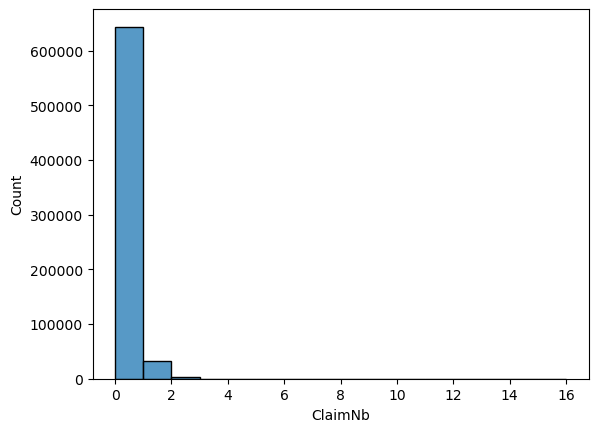

```python
sns.histplot(df_freq,x="ClaimNb",bins=16)
plt.show()
```

```python
df_freq.ClaimNb.value_counts()
```

```
0     643953
1      32178
2       3082
3        206
11        23
4         22
16        16
5         10
9          9
8          8
6          6
Name: ClaimNb, dtype: int64
```

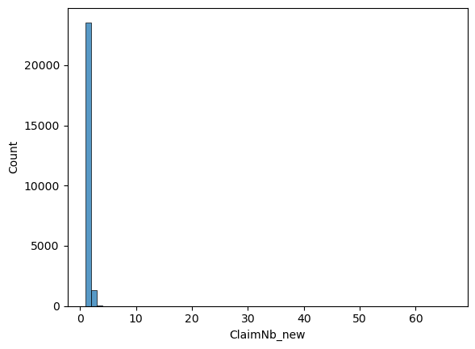

```python
sns.histplot(df_sev_combined,x="ClaimNb_new",bins=66)
plt.show()
```

Most customers in df_freq have not made claims perviously. Less than 10% of customers have made a claim. This does not mean, that the rest should not pay anything for their insurance policy, because there is still a change that the will get into an accident in the future. To address this, they also have to pay a certain amount, yet less than customers who have made claims before and who may have a higher risk

```python
df_sev.ClaimAmount.describe(include="all")
```

```
count    2.644400e+04
mean     2.265513e+03
std      2.937103e+04
min      1.000000e+00
25%      6.859925e+02
50%      1.172000e+03
75%      1.212385e+03
max      4.075401e+06
Name: ClaimAmount, dtype: float64
```

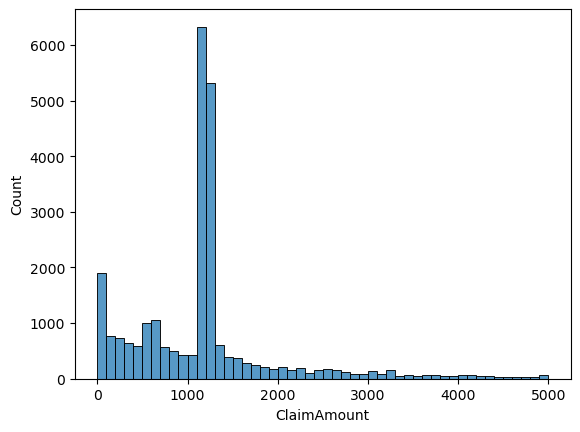

```python
sns.histplot(df_sev,x="ClaimAmount",binrange=(0,5000),bins=50)
plt.show()
```

Somewhat surprisingly to me the distribution shows a clear peak at about 1200. It is possible that for most smaller claims customers pay damages out of pocket in order to keep their Bonus Malus. Another explaination is that even smaller damages can require standard paperwork for repair shops, so that they charge a fixed price even if the job is small.

### Exposure

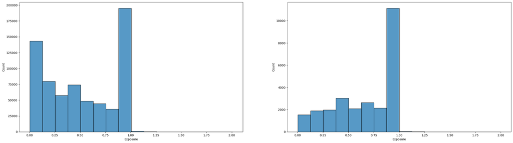

```python
fig,(ax1,ax2) = plt.subplots(1,2)
fig.set_figwidth(30)
fig.set_figheight(8)
sns.histplot(df_freq,x="Exposure",bins=16,ax=ax1)
sns.histplot(df_sev,x="Exposure",bins=16,ax=ax2)
plt.show()
```

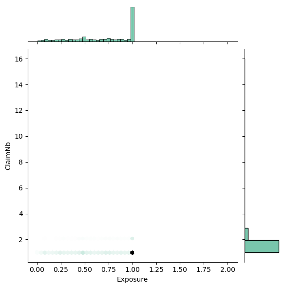

```python
sns.jointplot(x="Exposure", y="ClaimNb", kind="hex", color="#4CB391",data=df_sev)
```

The Exposure defines the time each customer is insured by this company. Surprisingly most customers seem to be insured for less than one year, while most claims are made by the customer after one year of being insured. This is overproportionally if we compare the frame of new claims with the frame of all customers

### Area, Region and density

While the data set does not contain Personal Information like names, ethnicity or address, it contains high level geoinformation like an Area and Region code as well as the population density.

#### Area

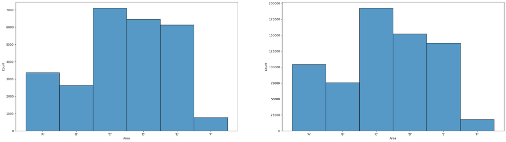

```python
df_sev.sort_values("Area",inplace=True)
df_freq.sort_values("Area",inplace=True)
fig,(ax1,ax2) = plt.subplots(1,2)
fig.set_figwidth(30)
fig.set_figheight(8)
sns.histplot(df_sev,x="Area",ax=ax1)
sns.histplot(df_freq,x="Area",ax=ax2)
plt.show()
```

```python
combined_one = df_freq.groupby("Area")["IDpol"].count().reset_index()
combined_one["Percent Customers"]=combined_one["IDpol"]/df_freq.shape[0]
combined_one.drop(columns=["IDpol"],inplace=True)
combined_two = df_sev.groupby("Area")["IDpol"].count().reset_index()
combined_two["Percent Claims"]=combined_two["IDpol"]/df_sev.shape[0]
combined_two.drop(columns=["IDpol"],inplace=True)
df_combined = pd.merge(combined_one,combined_two,how="outer",on="Area")
df_combined.head(10)
```

|  | Area | Percent Customers | Percent Claims |
| --- | --- | --- | --- |
| 0 | 'A' | 0.153174 | 0.127212 |
| 1 | 'B' | 0.111209 | 0.099569 |
| 2 | 'C' | 0.282913 | 0.268227 |
| 3 | 'D' | 0.223706 | 0.244214 |
| 4 | 'E' | 0.202486 | 0.231508 |
| 5 | 'F' | 0.026512 | 0.029269 |

While the Areas A,B,C have a lower proportion of claims in regard to the percentage of customers, the Areas D,E and F have a higher proportion of claims in regard to the percentage of customers

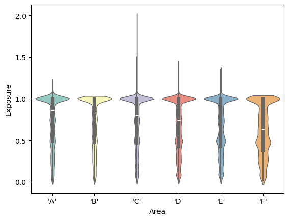

```python
sns.violinplot(data=df_sev, x="Area",y="Exposure", bw_adjust=.5, cut=1, linewidth=1, palette="Set3")
plt.show()
```

While i can't visualize the claim amount distribution as easily, i can show that the distribution of the exposure between each Area seems similar. Only Area F has a higher Percentage of customers with less than 1 year of being insured by this company

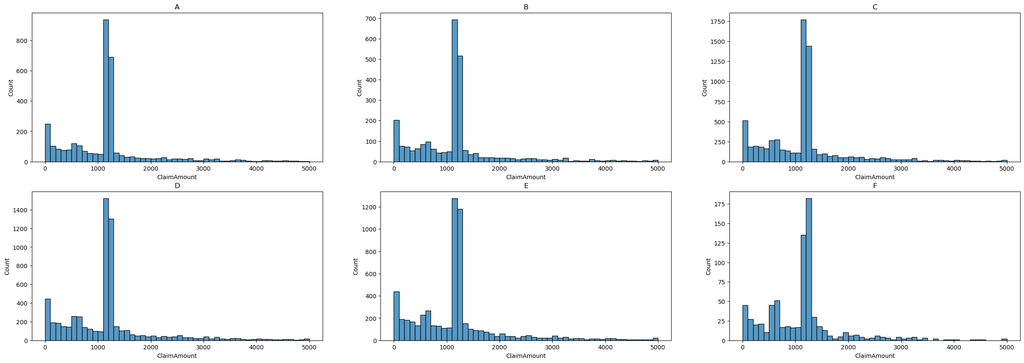

```python
df_A = df_sev[df_sev["Area"]=="'A'"]
df_B = df_sev[df_sev["Area"]=="'B'"]
df_C = df_sev[df_sev["Area"]=="'C'"]
df_D = df_sev[df_sev["Area"]=="'D'"]
df_E = df_sev[df_sev["Area"]=="'E'"]
df_F = df_sev[df_sev["Area"]=="'F'"]
fig,axs = plt.subplots(2,3)
fig.set_figwidth(30)
fig.set_figheight(10)
sns.histplot(df_A,x="ClaimAmount",binrange=(0,5000),bins=50,ax=axs[0,0])
sns.histplot(df_B,x="ClaimAmount",binrange=(0,5000),bins=50,ax=axs[0,1])
sns.histplot(df_C,x="ClaimAmount",binrange=(0,5000),bins=50,ax=axs[0,2])
sns.histplot(df_D,x="ClaimAmount",binrange=(0,5000),bins=50,ax=axs[1,0])
sns.histplot(df_E,x="ClaimAmount",binrange=(0,5000),bins=50,ax=axs[1,1])
sns.histplot(df_F,x="ClaimAmount",binrange=(0,5000),bins=50,ax=axs[1,2])
axs[0,0].set_title("A")
axs[0,1].set_title("B")
axs[0,2].set_title("C")
axs[1,0].set_title("D")
axs[1,1].set_title("E")
axs[1,2].set_title("F")
plt.show()
```

#### Region

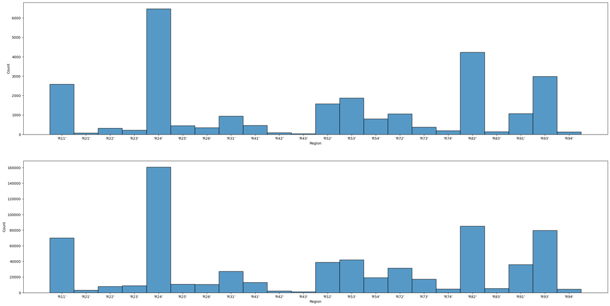

```python
df_sev.sort_values("Region",inplace=True)
df_freq.sort_values("Region",inplace=True)
fig,(ax1,ax2) = plt.subplots(2,1)
fig.set_figwidth(30)
fig.set_figheight(15)
sns.histplot(df_sev,x="Region",ax=ax1)
sns.histplot(df_freq,x="Region",ax=ax2)
plt.show()
```

No obvious differences that seem to be worth exploring

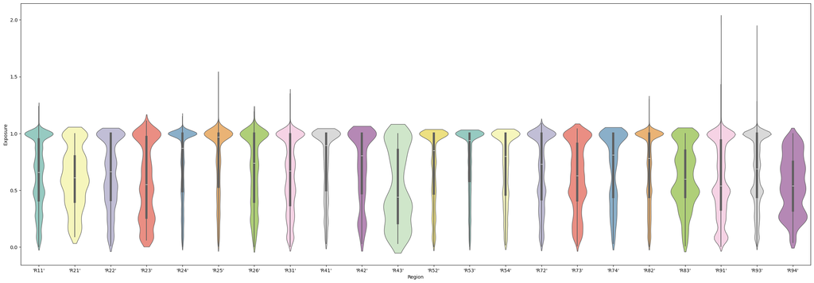

```python
fig=plt.figure(figsize=(30,10))
sns.violinplot(data=df_sev, x="Region",y="Exposure", bw_adjust=.5, cut=1, linewidth=1, palette="Set3")
plt.show()
```

While the Exposure is not that different between Areas, we can se a bigger difference between Regions

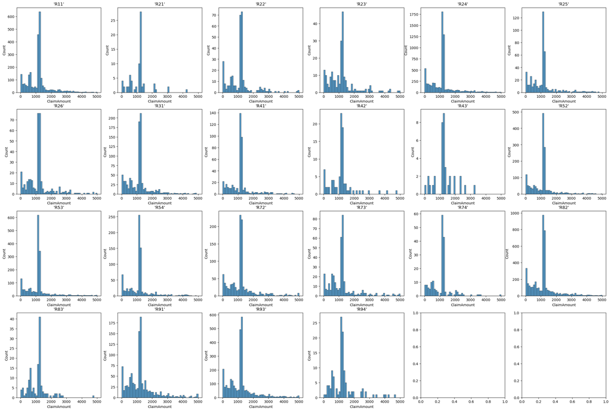

```python
regions = df_sev.Region.unique()
df_regions = []

fig,axs = plt.subplots(4,6)
fig.set_figwidth(30)
fig.set_figheight(20)

for i in range(len(regions)):
    df_temp = df_sev[df_sev["Region"]==regions[i]]
    y = i%6
    x=int(i/6)
    sns.histplot(df_temp,x="ClaimAmount",binrange=(0,5000),bins=50,ax=axs[x,y])
    axs[x,y].set_title(regions[i])
```

No big differences to see here

But before i continue, are Regions unique to Areas?

```python
df_combined = df_sev.groupby(["Area","Region"])["IDpol"].count().reset_index()
df_combined = df_combined.pivot(index="Area",columns="Region",values="IDpol")
df_combined = df_combined.fillna(0.0)
df_combined.style.background_gradient(axis=0)
```

| Region Area | 'R11' | 'R21' | 'R22' | 'R23' | 'R24' | 'R25' | 'R26' | 'R31' | 'R41' | 'R42' | 'R43' | 'R52' | 'R53' | 'R54' | 'R72' | 'R73' | 'R74' | 'R82' | 'R83' | 'R91' | 'R93' | 'R94' |
| --- | --- | --- | --- | --- | --- | --- | --- | --- | --- | --- | --- | --- | --- | --- | --- | --- | --- | --- | --- | --- | --- | --- |
| 'A' | 37.000000 | 24.000000 | 42.000000 | 29.000000 | 1890.000000 | 67.000000 | 97.000000 | 20.000000 | 17.000000 | 1.000000 | 11.000000 | 138.000000 | 113.000000 | 148.000000 | 155.000000 | 65.000000 | 88.000000 | 198.000000 | 43.000000 | 62.000000 | 89.000000 | 30.000000 |
| 'B' | 72.000000 | 9.000000 | 62.000000 | 30.000000 | 971.000000 | 73.000000 | 46.000000 | 55.000000 | 26.000000 | 7.000000 | 3.000000 | 210.000000 | 287.000000 | 120.000000 | 121.000000 | 49.000000 | 9.000000 | 252.000000 | 20.000000 | 69.000000 | 127.000000 | 15.000000 |
| 'C' | 221.000000 | 19.000000 | 60.000000 | 58.000000 | 1890.000000 | 146.000000 | 145.000000 | 211.000000 | 141.000000 | 22.000000 | 14.000000 | 451.000000 | 869.000000 | 201.000000 | 296.000000 | 97.000000 | 76.000000 | 1019.000000 | 29.000000 | 444.000000 | 650.000000 | 34.000000 |
| 'D' | 404.000000 | 15.000000 | 57.000000 | 41.000000 | 1221.000000 | 104.000000 | 16.000000 | 415.000000 | 259.000000 | 19.000000 | 5.000000 | 433.000000 | 377.000000 | 305.000000 | 186.000000 | 66.000000 | 24.000000 | 1261.000000 | 21.000000 | 405.000000 | 771.000000 | 53.000000 |
| 'E' | 1083.000000 | 10.000000 | 93.000000 | 62.000000 | 503.000000 | 62.000000 | 41.000000 | 243.000000 | 25.000000 | 43.000000 | 5.000000 | 344.000000 | 225.000000 | 26.000000 | 297.000000 | 92.000000 | 0.000000 | 1503.000000 | 28.000000 | 88.000000 | 1349.000000 | 0.000000 |
| 'F' | 774.000000 | 0.000000 | 0.000000 | 0.000000 | 0.000000 | 0.000000 | 0.000000 | 0.000000 | 0.000000 | 0.000000 | 0.000000 | 0.000000 | 0.000000 | 0.000000 | 0.000000 | 0.000000 | 0.000000 | 0.000000 | 0.000000 | 0.000000 | 0.000000 | 0.000000 |

Answer: No, but no idea why

#### Density

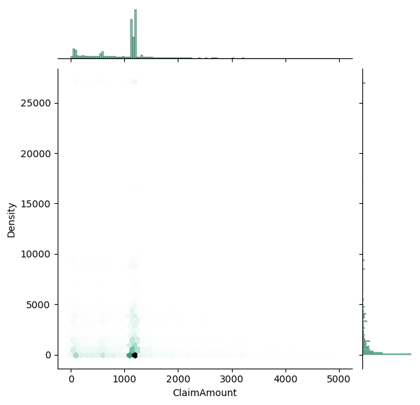

```python
df_sev_spezial = df_sev[df_sev["ClaimAmount"]<5000]
sns.jointplot(x="ClaimAmount", y="Density", kind="hex", color="#4CB391",data=df_sev_spezial)
```

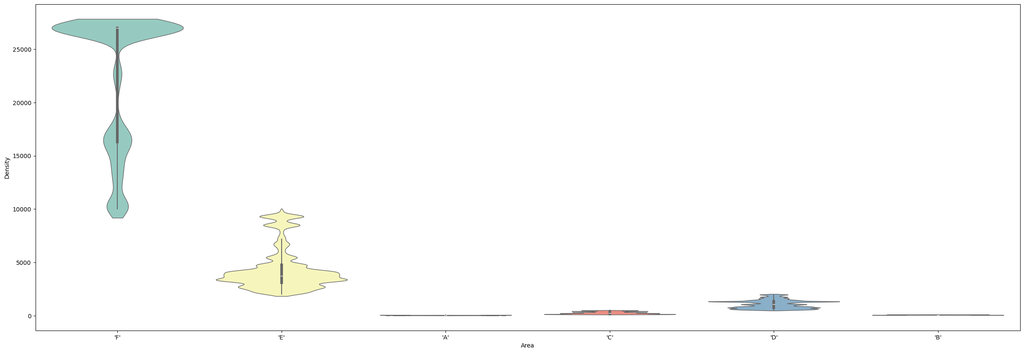

```python
fig=plt.figure(figsize=(30,10))
sns.violinplot(data=df_sev, x="Area",y="Density", bw_adjust=.5, cut=1, linewidth=1, palette="Set3")
plt.show()
```

Regarding the density, Areas seem to have hugh differences. But interestingly enough, we know that Regions are not unique to Areas. Maybe Areas are clusters with different feature values

### Vehicles

Regarding the vehicles the data set contains several informations.

1. Power
2. Vehicle Age
3. Brand
4. Fuel Type

#### Power

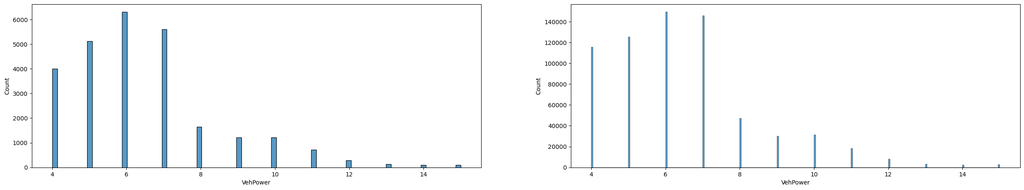

```python
fig,(ax1,ax2) = plt.subplots(1,2)
fig.set_figwidth(30)
fig.set_figheight(5)
sns.histplot(df_sev,x="VehPower",ax=ax1)
sns.histplot(df_freq,x="VehPower",ax=ax2)
plt.show()
```

Between both frames, there is no big difference in the vehicle power distribution. This does not suggest that we have a big difference in risk in regard to the vehicle power

```python
combined_one = df_freq.groupby("VehPower")["IDpol"].count().reset_index()
combined_one["Percent Customers"]=combined_one["IDpol"]/df_freq.shape[0]
combined_one.drop(columns=["IDpol"],inplace=True)
combined_two = df_sev.groupby("VehPower")["IDpol"].count().reset_index()
combined_two["Percent Claims"]=combined_two["IDpol"]/df_sev.shape[0]
combined_two.drop(columns=["IDpol"],inplace=True)
df_combined = pd.merge(combined_one,combined_two,how="outer",on="VehPower")
#df_combined.head(10)
df_combined.style.background_gradient(axis=0)
```

|  | VehPower | Percent Customers | Percent Claims |
| --- | --- | --- | --- |
| 0 | 4 | 0.170181 | 0.151376 |
| 1 | 5 | 0.184104 | 0.193428 |
| 2 | 6 | 0.219724 | 0.238428 |
| 3 | 7 | 0.214399 | 0.211504 |
| 4 | 8 | 0.069235 | 0.062207 |
| 5 | 9 | 0.044366 | 0.046135 |
| 6 | 10 | 0.046260 | 0.046022 |
| 7 | 11 | 0.027080 | 0.027000 |
| 8 | 12 | 0.012113 | 0.011193 |
| 9 | 13 | 0.004759 | 0.005256 |
| 10 | 14 | 0.003470 | 0.003819 |
| 11 | 15 | 0.004310 | 0.003630 |

#### Vehicle Age

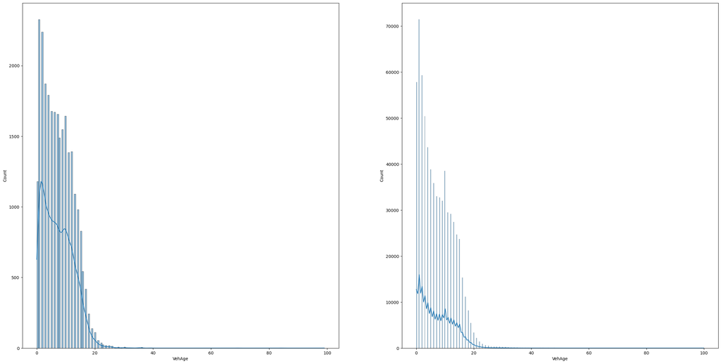

```python
fig,(ax1,ax2) = plt.subplots(1,2)
fig.set_figwidth(30)
fig.set_figheight(15)
sns.histplot(df_sev,x="VehAge",kde=True,ax=ax1)
sns.histplot(df_freq,x="VehAge",kde=True,ax=ax2)
plt.show()
```

The distribution of Vehicle Age between both frames has a similar form, but not quite

```python
combined_one = df_freq.groupby("VehAge")["IDpol"].count().reset_index()
combined_one["Percent Customers"]=combined_one["IDpol"]/df_freq.shape[0]
combined_one.drop(columns=["IDpol"],inplace=True)
combined_two = df_sev.groupby("VehAge")["IDpol"].count().reset_index()
combined_two["Percent Claims"]=combined_two["IDpol"]/df_sev.shape[0]
combined_two.drop(columns=["IDpol"],inplace=True)
df_combined = pd.merge(combined_one,combined_two,how="outer",on="VehAge")
df_combined.fillna(0.0,inplace=True)
#df_combined.head(10)
df_combined.style.background_gradient(axis=0)
```

|  | VehAge | Percent Customers | Percent Claims |
| --- | --- | --- | --- |
| 0 | 0 | 0.085080 | 0.044660 |
| 1 | 1 | 0.105134 | 0.088035 |
| 2 | 2 | 0.087239 | 0.084632 |
| 3 | 3 | 0.074122 | 0.070829 |
| 4 | 4 | 0.064164 | 0.067804 |
| 5 | 5 | 0.057145 | 0.063455 |
| 6 | 6 | 0.052704 | 0.063190 |
| 7 | 7 | 0.048535 | 0.062661 |
| 8 | 8 | 0.048180 | 0.056308 |
| 9 | 9 | 0.047104 | 0.058577 |
| 10 | 10 | 0.056638 | 0.062131 |
| 11 | 11 | 0.043384 | 0.052413 |
| 12 | 12 | 0.042931 | 0.052677 |
| 13 | 13 | 0.040347 | 0.041295 |
| 14 | 14 | 0.036263 | 0.037097 |
| 15 | 15 | 0.034825 | 0.031311 |
| 16 | 16 | 0.022493 | 0.020572 |
| 17 | 17 | 0.016447 | 0.015845 |
| 18 | 18 | 0.012057 | 0.009189 |
| 19 | 19 | 0.007987 | 0.005256 |
| 20 | 20 | 0.004958 | 0.004235 |
| 21 | 21 | 0.003251 | 0.002042 |
| 22 | 22 | 0.002100 | 0.001437 |
| 23 | 23 | 0.001354 | 0.000908 |
| 24 | 24 | 0.000970 | 0.000718 |
| 25 | 25 | 0.000731 | 0.000681 |
| 26 | 26 | 0.000545 | 0.000529 |
| 27 | 27 | 0.000480 | 0.000113 |
| 28 | 28 | 0.000409 | 0.000265 |
| 29 | 29 | 0.000414 | 0.000076 |
| 30 | 30 | 0.000368 | 0.000265 |
| 31 | 31 | 0.000319 | 0.000076 |
| 32 | 32 | 0.000225 | 0.000113 |
| 33 | 33 | 0.000182 | 0.000076 |
| 34 | 34 | 0.000152 | 0.000000 |
| 35 | 35 | 0.000138 | 0.000151 |
| 36 | 36 | 0.000106 | 0.000189 |
| 37 | 37 | 0.000069 | 0.000000 |
| 38 | 38 | 0.000053 | 0.000000 |
| 39 | 39 | 0.000037 | 0.000076 |
| 40 | 40 | 0.000024 | 0.000000 |
| 41 | 41 | 0.000012 | 0.000000 |
| 42 | 42 | 0.000019 | 0.000000 |
| 43 | 43 | 0.000022 | 0.000000 |
| 44 | 44 | 0.000022 | 0.000000 |
| 45 | 45 | 0.000018 | 0.000000 |
| 46 | 46 | 0.000028 | 0.000000 |
| 47 | 47 | 0.000021 | 0.000000 |
| 48 | 48 | 0.000025 | 0.000000 |
| 49 | 49 | 0.000018 | 0.000000 |
| 50 | 50 | 0.000012 | 0.000000 |
| 51 | 51 | 0.000006 | 0.000000 |
| 52 | 52 | 0.000009 | 0.000000 |
| 53 | 53 | 0.000003 | 0.000000 |
| 54 | 54 | 0.000003 | 0.000000 |
| 55 | 55 | 0.000001 | 0.000000 |
| 56 | 59 | 0.000003 | 0.000000 |
| 57 | 60 | 0.000001 | 0.000000 |
| 58 | 62 | 0.000001 | 0.000000 |
| 59 | 63 | 0.000001 | 0.000000 |
| 60 | 64 | 0.000001 | 0.000000 |
| 61 | 65 | 0.000003 | 0.000000 |
| 62 | 66 | 0.000003 | 0.000000 |
| 63 | 68 | 0.000003 | 0.000000 |
| 64 | 69 | 0.000006 | 0.000038 |
| 65 | 70 | 0.000004 | 0.000000 |
| 66 | 71 | 0.000001 | 0.000000 |
| 67 | 76 | 0.000001 | 0.000000 |
| 68 | 78 | 0.000001 | 0.000000 |
| 69 | 79 | 0.000001 | 0.000000 |
| 70 | 80 | 0.000004 | 0.000000 |
| 71 | 81 | 0.000004 | 0.000000 |
| 72 | 82 | 0.000001 | 0.000000 |
| 73 | 83 | 0.000003 | 0.000000 |
| 74 | 84 | 0.000001 | 0.000038 |
| 75 | 85 | 0.000001 | 0.000000 |
| 76 | 99 | 0.000034 | 0.000038 |
| 77 | 100 | 0.000037 | 0.000000 |

```python
combined_one = df_freq.groupby("VehAge")["ClaimNb"].sum().reset_index()
combined_one["Percent Customers"]=combined_one["ClaimNb"]/df_freq.shape[0]
combined_one.drop(columns=["ClaimNb"],inplace=True)
combined_two = df_sev.groupby("VehAge")["ClaimNb_new"].sum().reset_index()
combined_two["Percent Claims"]=combined_two["ClaimNb_new"]/df_sev.shape[0]
combined_two.drop(columns=["ClaimNb_new"],inplace=True)
df_combined = pd.merge(combined_one,combined_two,how="outer",on="VehAge")
df_combined.fillna(0.0,inplace=True)
#df_combined.head(10)
df_combined.style.background_gradient(axis=0)
```

|  | VehAge | Percent Customers | Percent Claims |
| --- | --- | --- | --- |
| 0 | 0 | 0.007887 | 0.044660 |
| 1 | 1 | 0.004802 | 0.088035 |
| 2 | 2 | 0.004568 | 0.084632 |
| 3 | 3 | 0.003732 | 0.070829 |
| 4 | 4 | 0.003694 | 0.067804 |
| 5 | 5 | 0.003442 | 0.063455 |
| 6 | 6 | 0.003416 | 0.063190 |
| 7 | 7 | 0.003263 | 0.062661 |
| 8 | 8 | 0.002880 | 0.056308 |
| 9 | 9 | 0.002967 | 0.058577 |
| 10 | 10 | 0.003342 | 0.062131 |
| 11 | 11 | 0.002597 | 0.052413 |
| 12 | 12 | 0.003213 | 0.052677 |
| 13 | 13 | 0.002338 | 0.041295 |
| 14 | 14 | 0.001801 | 0.037097 |
| 15 | 15 | 0.001535 | 0.031311 |
| 16 | 16 | 0.000992 | 0.020572 |
| 17 | 17 | 0.000759 | 0.015845 |
| 18 | 18 | 0.000436 | 0.009189 |
| 19 | 19 | 0.000250 | 0.005256 |
| 20 | 20 | 0.000196 | 0.004235 |
| 21 | 21 | 0.000116 | 0.002042 |
| 22 | 22 | 0.000072 | 0.001437 |
| 23 | 23 | 0.000046 | 0.000908 |
| 24 | 24 | 0.000037 | 0.000718 |
| 25 | 25 | 0.000049 | 0.000681 |
| 26 | 26 | 0.000032 | 0.000529 |
| 27 | 27 | 0.000007 | 0.000113 |
| 28 | 28 | 0.000013 | 0.000265 |
| 29 | 29 | 0.000007 | 0.000076 |
| 30 | 30 | 0.000019 | 0.000265 |
| 31 | 31 | 0.000004 | 0.000076 |
| 32 | 32 | 0.000004 | 0.000113 |
| 33 | 33 | 0.000009 | 0.000076 |
| 34 | 34 | 0.000000 | 0.000000 |
| 35 | 35 | 0.000006 | 0.000151 |
| 36 | 36 | 0.000010 | 0.000189 |
| 37 | 37 | 0.000003 | 0.000000 |
| 38 | 38 | 0.000000 | 0.000000 |
| 39 | 39 | 0.000003 | 0.000076 |
| 40 | 40 | 0.000000 | 0.000000 |
| 41 | 41 | 0.000000 | 0.000000 |
| 42 | 42 | 0.000001 | 0.000000 |
| 43 | 43 | 0.000000 | 0.000000 |
| 44 | 44 | 0.000000 | 0.000000 |
| 45 | 45 | 0.000000 | 0.000000 |
| 46 | 46 | 0.000000 | 0.000000 |
| 47 | 47 | 0.000000 | 0.000000 |
| 48 | 48 | 0.000000 | 0.000000 |
| 49 | 49 | 0.000000 | 0.000000 |
| 50 | 50 | 0.000000 | 0.000000 |
| 51 | 51 | 0.000000 | 0.000000 |
| 52 | 52 | 0.000000 | 0.000000 |
| 53 | 53 | 0.000000 | 0.000000 |
| 54 | 54 | 0.000000 | 0.000000 |
| 55 | 55 | 0.000000 | 0.000000 |
| 56 | 59 | 0.000000 | 0.000000 |
| 57 | 60 | 0.000000 | 0.000000 |
| 58 | 62 | 0.000000 | 0.000000 |
| 59 | 63 | 0.000000 | 0.000000 |
| 60 | 64 | 0.000000 | 0.000000 |
| 61 | 65 | 0.000000 | 0.000000 |
| 62 | 66 | 0.000000 | 0.000000 |
| 63 | 68 | 0.000000 | 0.000000 |
| 64 | 69 | 0.000001 | 0.000038 |
| 65 | 70 | 0.000000 | 0.000000 |
| 66 | 71 | 0.000000 | 0.000000 |
| 67 | 76 | 0.000000 | 0.000000 |
| 68 | 78 | 0.000000 | 0.000000 |
| 69 | 79 | 0.000000 | 0.000000 |
| 70 | 80 | 0.000000 | 0.000000 |
| 71 | 81 | 0.000000 | 0.000000 |
| 72 | 82 | 0.000000 | 0.000000 |
| 73 | 83 | 0.000000 | 0.000000 |
| 74 | 84 | 0.000001 | 0.000038 |
| 75 | 85 | 0.000000 | 0.000000 |
| 76 | 99 | 0.000001 | 0.000038 |
| 77 | 100 | 0.000000 | 0.000000 |

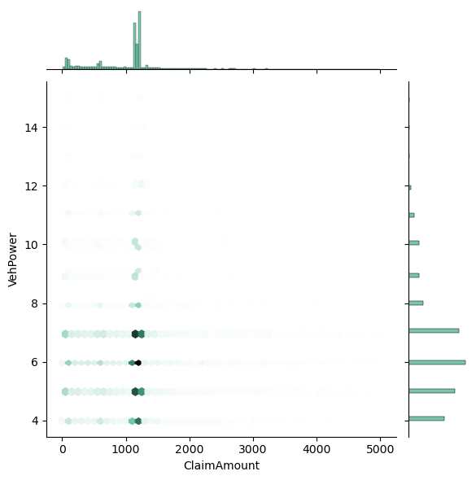

```python
df_sev_spezial = df_sev[df_sev["ClaimAmount"]<5000]
sns.jointplot(x="ClaimAmount", y="VehPower", kind="hex", color="#4CB391",data=df_sev_spezial)
```

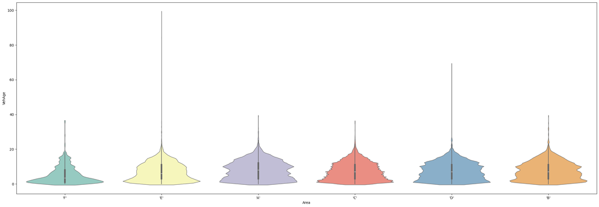

```python
fig=plt.figure(figsize=(30,10))
sns.violinplot(data=df_sev, x="Area",y="VehAge", bw_adjust=.5, cut=1, linewidth=1, palette="Set3")
plt.show()
```

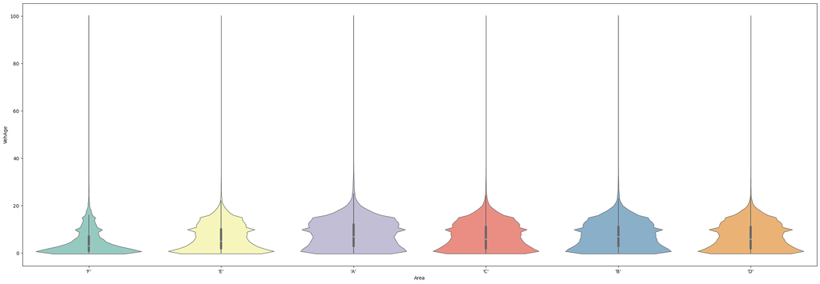

```python
fig=plt.figure(figsize=(30,10))
sns.violinplot(data=df_freq, x="Area",y="VehAge", bw_adjust=.5, cut=1, linewidth=1, palette="Set3")
plt.show()
```

The distribution of the vehicle age over each area seems to be similar

#### Brand

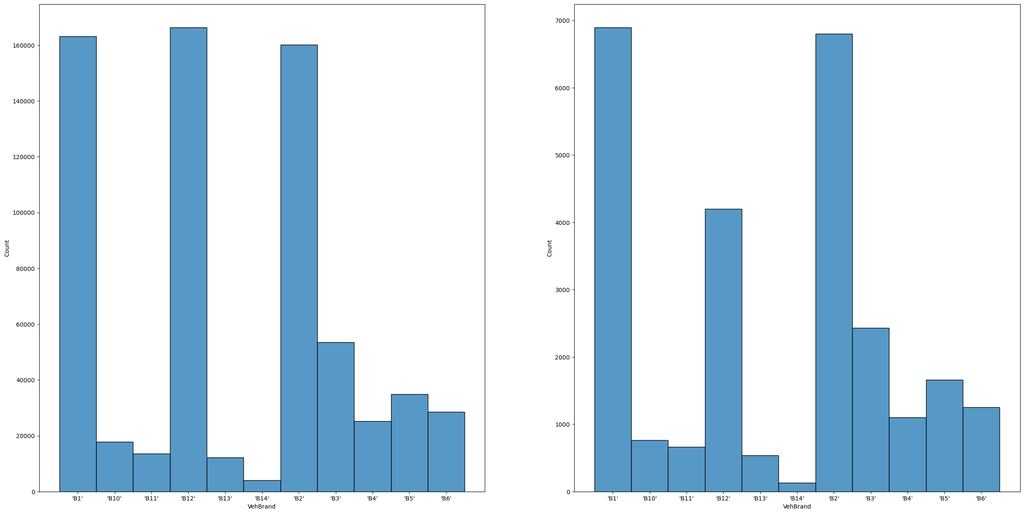

```python
df_freq.sort_values("VehBrand",inplace=True)
df_sev.sort_values("VehBrand",inplace=True)
fig,(ax1,ax2) = plt.subplots(1,2)
fig.set_figwidth(30)
fig.set_figheight(15)
sns.histplot(df_freq,x="VehBrand",ax=ax1)
sns.histplot(df_sev,x="VehBrand",ax=ax2)
plt.show()
```

For the vehicle Brands i can only see one significant difference. Vehicle Brand B12 seems to have fewer claims proportionaly to it's percentage over all customers. This could mean that B12 is safer or bares less risk

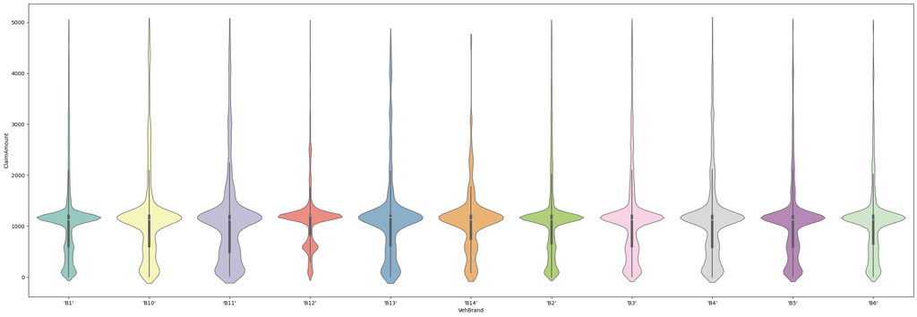

```python
fig=plt.figure(figsize=(30,10))
df_sev_spezial = df_sev[df_sev["ClaimAmount"]<5000]
sns.violinplot(data=df_sev_spezial, x="VehBrand",y="ClaimAmount", bw_adjust=.5, cut=1, linewidth=1, palette="Set3")
plt.show()
```

Vehicle Brands don't seem to have much influence in the claim amount, if we apply a cutoff at 5k

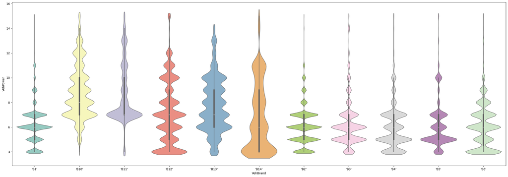

```python
fig=plt.figure(figsize=(30,10))
sns.violinplot(data=df_sev_spezial, x="VehBrand",y="VehPower", bw_adjust=.5, cut=1, linewidth=1, palette="Set3")
plt.show()
```

Regarding the power, there is a clear difference between brands

#### Fuel Type

```python
df_sev.VehGas.value_counts()
```

```
Diesel     13450
Regular    12994
Name: VehGas, dtype: int64
```

```python
df_freq.VehGas.value_counts()
```

```
Regular    346627
Diesel     332886
Name: VehGas, dtype: int64
```

While Regular fuel is a little bit more popular over all vehicles, Diesel car have a higher proportion of claims

```python
df_combined = df_freq.groupby(["VehBrand","VehGas"])["IDpol"].count().reset_index()
df_combined = df_combined.pivot(index="VehGas",columns="VehBrand",values="IDpol")
df_combined = df_combined.fillna(0.0)
df_combined.style.background_gradient(axis=None)
```

| VehBrand VehGas | 'B1' | 'B10' | 'B11' | 'B12' | 'B13' | 'B14' | 'B2' | 'B3' | 'B4' | 'B5' | 'B6' |
| --- | --- | --- | --- | --- | --- | --- | --- | --- | --- | --- | --- |
| Diesel | 75687 | 13050 | 6733 | 75558 | 6100 | 1301 | 84980 | 29872 | 11384 | 16842 | 11379 |
| Regular | 87438 | 4690 | 6890 | 90840 | 6106 | 2750 | 75199 | 23648 | 13841 | 17993 | 17232 |

Only a handful of brands seems to diverge from this distribution

### Driver

For the Driver we have two features that describe the driver. His/her age and the Bonus Malus that reduces the yearly amount to pay for the insurance policy.

#### Driver Age

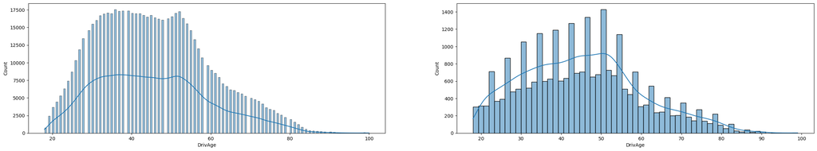

```python
df_freq.sort_values("VehBrand",inplace=True)
df_sev.sort_values("VehBrand",inplace=True)
fig,(ax1,ax2) = plt.subplots(1,2)
fig.set_figwidth(30)
fig.set_figheight(5)
sns.histplot(df_freq,x="DrivAge",kde=True,ax=ax1)
sns.histplot(df_sev,x="DrivAge",kde=True,ax=ax2)
plt.show()
```

```python
df_freq.DrivAge.value_counts()
```

```
36     17559
38     17373
39     17347
37     17330
52     17267
       ...
95        24
96        15
97        10
98         5
100        3
Name: DrivAge, Length: 83, dtype: int64
```

```python
df_sev.DrivAge.value_counts()
```

```
51    732
52    727
47    721
45    709
50    695
     ...
91      8
99      4
95      2
94      1
93      1
Name: DrivAge, Length: 78, dtype: int64
```

While the insurance have almost the same number of customers with the age around 30 and 50, customers around 50 have a higher number of claims in the second frame, which indicates that they have a higher risk

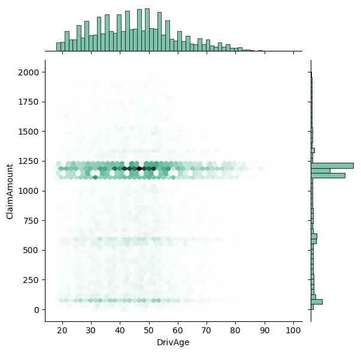

```python
df_sev_spezial = df_sev[df_sev["ClaimAmount"]<2000]
sns.jointplot(x="DrivAge", y="ClaimAmount", kind="hex", color="#4CB391",data=df_sev_spezial)
```

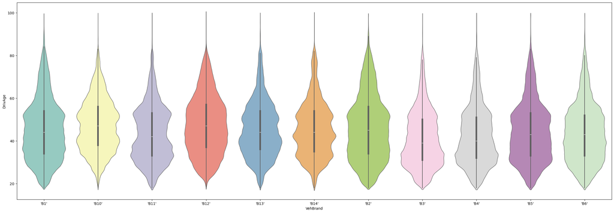

```python
fig=plt.figure(figsize=(30,10))
sns.violinplot(data=df_freq, x="VehBrand",y="DrivAge", bw_adjust=.5, cut=1, linewidth=1, palette="Set3")
plt.show()
```

As shown in this graph the age distribution between brands are different, which show that different brands are favoured by diffent agegroups, but in most cases these differences are only small.

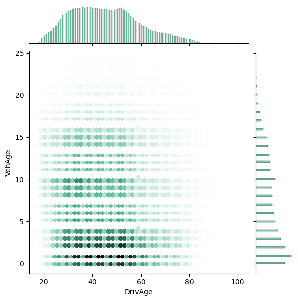

```python
df_freq_spezial = df_freq[df_freq["VehAge"]<25]
ax = sns.jointplot(x="DrivAge", y="VehAge", kind="hex", color="#4CB391",data=df_freq_spezial)
```

A little bit more of a difference we can see when we try to analyse the vehicle age in regard to the drivers age. While the hexbinplot is still hard to read, we can see, that younger cars (0-5 years) are most often bought by people between 30 and 50 years, while younger people seem to start more often with used cars.

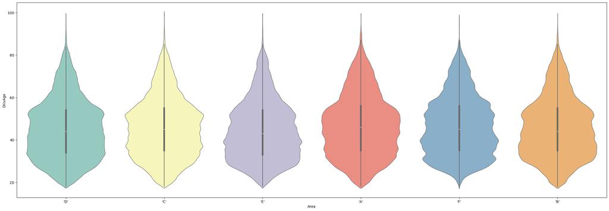

```python
fig=plt.figure(figsize=(30,10))
sns.violinplot(data=df_freq, x="Area",y="DrivAge", bw_adjust=.5, cut=1, linewidth=1, palette="Set3")
plt.show()
```

If i plot the driver age distribution for each area, we can see that again the distributions are similar and in general show the expected demographic distribution. Only small differences between agegroups can be seen.

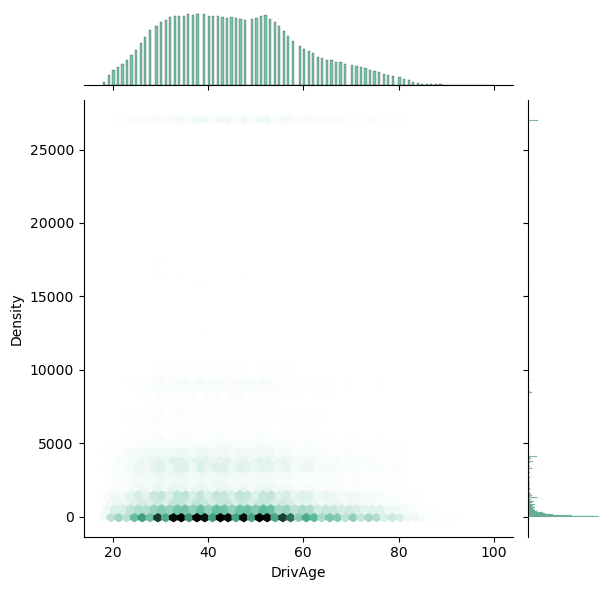

```python
sns.jointplot(x="DrivAge", y="Density", kind="hex", color="#4CB391",data=df_freq)
plt.show()
```

The hexbin plot for Driver Age vs the Population density seems to show a similar picture.

#### Bonus Malus

The Bonus Malus is artificial factor that reduces the yearly amount to pay for the insurance policy. The factor is based on the number of years without a claim.

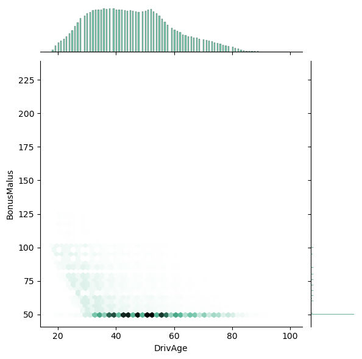

```python
sns.jointplot(x="DrivAge", y="BonusMalus", kind="hex", color="#4CB391",data=df_freq)
```

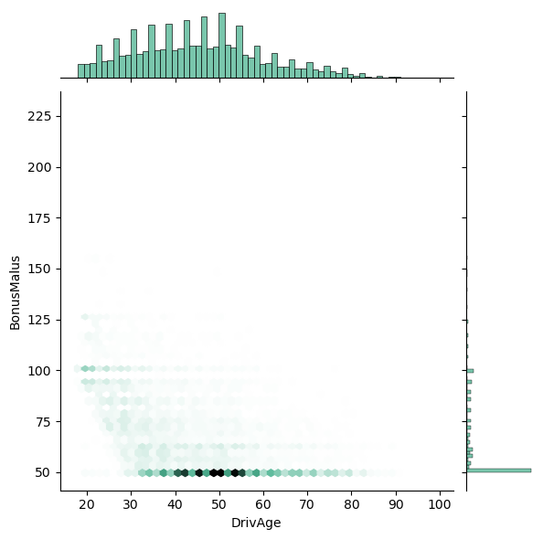

```python
sns.jointplot(x="DrivAge", y="BonusMalus", kind="hex", color="#4CB391",data=df_sev)
```

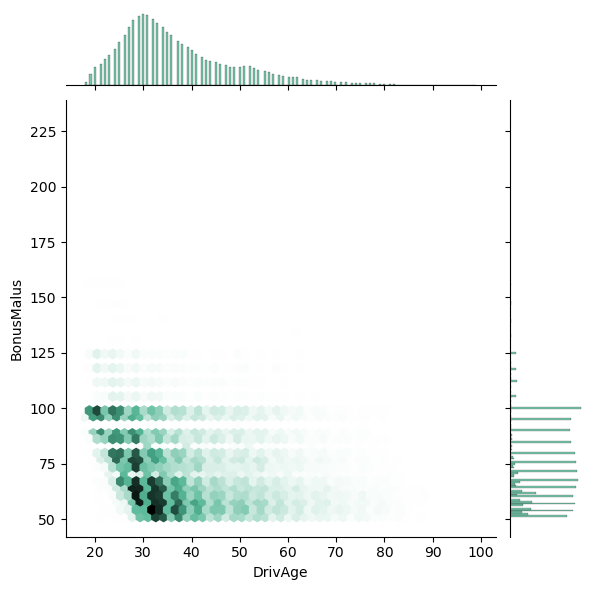

```python
df_freq_spezial = df_freq[df_freq["BonusMalus"]>50]
sns.jointplot(x="DrivAge", y="BonusMalus", kind="hex", color="#4CB391",data=df_freq_spezial)
```

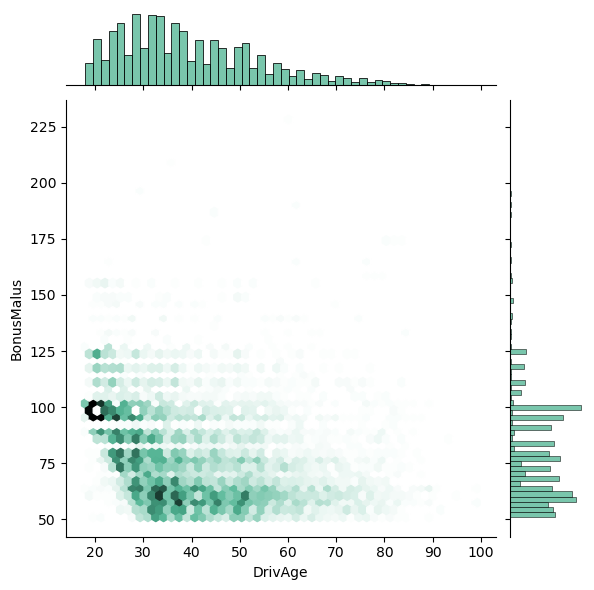

```python
df_sev_spezial = df_sev[df_sev["BonusMalus"]>50]
sns.jointplot(x="DrivAge", y="BonusMalus", kind="hex", color="#4CB391",data=df_sev_spezial)
```

As we can see the drivers usually take at least ten years to reach the minimum Bonus Malus of 50. We can also see, that the maximum Bonus Malus with each agegroup shows a downward trend with increasing age

## Feature Engineering

After i have extensivly explored the data, it is time for the feature engineering. As part of this i will choose the features for the machine learning

```python
%%time
df_freq_nummeric = df_freq.select_dtypes(include='number')
df_freq_nummeric.corr()
```

```
CPU times: user 84.4 ms, sys: 569 µs, total: 85 ms
Wall time: 84.2 ms
```

|  | IDpol | ClaimNb | Exposure | VehPower | VehAge | DrivAge | BonusMalus | Density | ClaimAmount | ClaimNb_new |
| --- | --- | --- | --- | --- | --- | --- | --- | --- | --- | --- |
| IDpol | 1.000000 | -0.110348 | -0.160259 | 0.048615 | -0.156947 | 0.063685 | -0.005848 | 0.070689 | -0.003892 | -0.041886 |
| ClaimNb | -0.110348 | 1.000000 | 0.063343 | -0.007582 | -0.016817 | 0.010298 | 0.052456 | 0.011675 | 0.060923 | 0.779022 |
| Exposure | -0.160259 | 0.063343 | 1.000000 | -0.045006 | 0.151258 | 0.171744 | -0.181478 | -0.070793 | 0.002231 | 0.089857 |
| VehPower | 0.048615 | -0.007582 | -0.045006 | 1.000000 | -0.006170 | 0.030077 | -0.075776 | 0.043043 | 0.001275 | 0.000974 |
| VehAge | -0.156947 | -0.016817 | 0.151258 | -0.006170 | 1.000000 | -0.059278 | 0.079943 | -0.090419 | 0.002322 | 0.011057 |
| DrivAge | 0.063685 | 0.010298 | 0.171744 | 0.030077 | -0.059278 | 1.000000 | -0.479625 | -0.004604 | -0.003660 | -0.005352 |
| BonusMalus | -0.005848 | 0.052456 | -0.181478 | -0.075776 | 0.079943 | -0.479625 | 1.000000 | 0.077753 | 0.009913 | 0.069954 |
| Density | 0.070689 | 0.011675 | -0.070793 | 0.043043 | -0.090419 | -0.004604 | 0.077753 | 1.000000 | -0.000063 | 0.011240 |
| ClaimAmount | -0.003892 | 0.060923 | 0.002231 | 0.001275 | 0.002322 | -0.003660 | 0.009913 | -0.000063 | 1.000000 | 0.075405 |
| ClaimNb_new | -0.041886 | 0.779022 | 0.089857 | 0.000974 | 0.011057 | -0.005352 | 0.069954 | 0.011240 | 0.075405 | 1.000000 |

```python
%%time
df_sev_nummeric = df_sev.select_dtypes(include='number')
df_sev_nummeric.corr()
```

```
CPU times: user 4.09 ms, sys: 0 ns, total: 4.09 ms
Wall time: 3.81 ms
```

|  | IDpol | ClaimAmount | ClaimNb_new | ClaimNb | Exposure | VehPower | VehAge | DrivAge | BonusMalus | Density |
| --- | --- | --- | --- | --- | --- | --- | --- | --- | --- | --- |
| IDpol | 1.000000 | -0.003868 | NaN | 0.042035 | -0.105313 | 0.058409 | -0.101092 | 0.054633 | -0.025426 | 0.067198 |
| ClaimAmount | -0.003868 | 1.000000 | NaN | 0.005014 | -0.026879 | 0.006213 | 0.008298 | -0.015929 | 0.018339 | -0.004403 |
| ClaimNb_new | NaN | NaN | NaN | NaN | NaN | NaN | NaN | NaN | NaN | NaN |
| ClaimNb | 0.042035 | 0.005014 | NaN | 1.000000 | -0.058165 | -0.047607 | 0.009920 | 0.011314 | 0.024418 | 0.015960 |
| Exposure | -0.105313 | -0.026879 | NaN | -0.058165 | 1.000000 | -0.009099 | 0.007270 | 0.188986 | -0.119041 | -0.046293 |
| VehPower | 0.058409 | 0.006213 | NaN | -0.047607 | -0.009099 | 1.000000 | -0.019775 | 0.021954 | -0.067810 | 0.048826 |
| VehAge | -0.101092 | 0.008298 | NaN | 0.009920 | 0.007270 | -0.019775 | 1.000000 | -0.072755 | 0.136393 | -0.078865 |
| DrivAge | 0.054633 | -0.015929 | NaN | 0.011314 | 0.188986 | 0.021954 | -0.072755 | 1.000000 | -0.469888 | 0.003977 |
| BonusMalus | -0.025426 | 0.018339 | NaN | 0.024418 | -0.119041 | -0.067810 | 0.136393 | -0.469888 | 1.000000 | 0.048121 |
| Density | 0.067198 | -0.004403 | NaN | 0.015960 | -0.046293 | 0.048826 | -0.078865 | 0.003977 | 0.048121 | 1.000000 |

In this case the correlation matrix is no good indicator for which features to choose. Instead i will choose the features based on the knowledge gained within the EDA. Based on the previous exploration i have decided to drop the Region column, convert the categorical features with dummy variables.

Additionally i will convert the Claim Amount to an expected Yearly Claim Amount by dividing with Exposure

```python
def convert_and_drop(df):
    df = df.drop(columns=["Region","IDpol"])
    df = pd.get_dummies(df,columns=["Area","VehBrand","VehGas"])
    df = df.astype("float32")
    return df

df_freq = convert_and_drop(df_freq)
df_sev = convert_and_drop(df_sev)
df_total = convert_and_drop(df_total)
df_total_zwei = convert_and_drop(df_total_zwei)

df_total["ClaimAmount_per_Year"] = df_total["ClaimAmount"]/df_total["Exposure"]
df_total_zwei["ClaimAmount_per_Year"] = df_total_zwei["ClaimAmount"]/df_total_zwei["Exposure"]
df_freq.drop(columns=["ClaimAmount","ClaimNb",],inplace=True)
df_total.drop(columns=["ClaimAmount","ClaimNb","ClaimNb_new"],inplace=True)
df_total_zwei.drop(columns=["ClaimAmount","ClaimNb","ClaimNb_new"],inplace=True)

#y = df_big["ClaimAmount_per_Year"]
#X = df_big.drop(columns=["IDpol","ClaimAmount","ClaimAmount_per_Year"])
```

### show feature frames

```python
df_total.head(50)
```

|  | Exposure | VehPower | VehAge | DrivAge | BonusMalus | Density | Area_'A' | Area_'B' | Area_'C' | Area_'D' | Area_'E' | Area_'F' | VehBrand_'B1' | VehBrand_'B10' | VehBrand_'B11' | VehBrand_'B12' | VehBrand_'B13' | VehBrand_'B14' | VehBrand_'B2' | VehBrand_'B3' | VehBrand_'B4' | VehBrand_'B5' | VehBrand_'B6' | VehGas_Diesel | VehGas_Regular | ClaimAmount_per_Year |
| --- | --- | --- | --- | --- | --- | --- | --- | --- | --- | --- | --- | --- | --- | --- | --- | --- | --- | --- | --- | --- | --- | --- | --- | --- | --- | --- |
| 0 | 0.10 | 5.0 | 0.0 | 55.0 | 50.0 | 1217.0 | 0.0 | 0.0 | 0.0 | 1.0 | 0.0 | 0.0 | 0.0 | 0.0 | 0.0 | 1.0 | 0.0 | 0.0 | 0.0 | 0.0 | 0.0 | 0.0 | 0.0 | 0.0 | 1.0 | 0.0 |
| 1 | 0.77 | 5.0 | 0.0 | 55.0 | 50.0 | 1217.0 | 0.0 | 0.0 | 0.0 | 1.0 | 0.0 | 0.0 | 0.0 | 0.0 | 0.0 | 1.0 | 0.0 | 0.0 | 0.0 | 0.0 | 0.0 | 0.0 | 0.0 | 0.0 | 1.0 | 0.0 |
| 2 | 0.75 | 6.0 | 2.0 | 52.0 | 50.0 | 54.0 | 0.0 | 1.0 | 0.0 | 0.0 | 0.0 | 0.0 | 0.0 | 0.0 | 0.0 | 1.0 | 0.0 | 0.0 | 0.0 | 0.0 | 0.0 | 0.0 | 0.0 | 1.0 | 0.0 | 0.0 |
| 3 | 0.09 | 7.0 | 0.0 | 46.0 | 50.0 | 76.0 | 0.0 | 1.0 | 0.0 | 0.0 | 0.0 | 0.0 | 0.0 | 0.0 | 0.0 | 1.0 | 0.0 | 0.0 | 0.0 | 0.0 | 0.0 | 0.0 | 0.0 | 1.0 | 0.0 | 0.0 |
| 4 | 0.84 | 7.0 | 0.0 | 46.0 | 50.0 | 76.0 | 0.0 | 1.0 | 0.0 | 0.0 | 0.0 | 0.0 | 0.0 | 0.0 | 0.0 | 1.0 | 0.0 | 0.0 | 0.0 | 0.0 | 0.0 | 0.0 | 0.0 | 1.0 | 0.0 | 0.0 |
| 5 | 0.52 | 6.0 | 2.0 | 38.0 | 50.0 | 3003.0 | 0.0 | 0.0 | 0.0 | 0.0 | 1.0 | 0.0 | 0.0 | 0.0 | 0.0 | 1.0 | 0.0 | 0.0 | 0.0 | 0.0 | 0.0 | 0.0 | 0.0 | 0.0 | 1.0 | 0.0 |
| 6 | 0.45 | 6.0 | 2.0 | 38.0 | 50.0 | 3003.0 | 0.0 | 0.0 | 0.0 | 0.0 | 1.0 | 0.0 | 0.0 | 0.0 | 0.0 | 1.0 | 0.0 | 0.0 | 0.0 | 0.0 | 0.0 | 0.0 | 0.0 | 0.0 | 1.0 | 0.0 |
| 7 | 0.27 | 7.0 | 0.0 | 33.0 | 68.0 | 137.0 | 0.0 | 0.0 | 1.0 | 0.0 | 0.0 | 0.0 | 0.0 | 0.0 | 0.0 | 1.0 | 0.0 | 0.0 | 0.0 | 0.0 | 0.0 | 0.0 | 0.0 | 1.0 | 0.0 | 0.0 |
| 8 | 0.71 | 7.0 | 0.0 | 33.0 | 68.0 | 137.0 | 0.0 | 0.0 | 1.0 | 0.0 | 0.0 | 0.0 | 0.0 | 0.0 | 0.0 | 1.0 | 0.0 | 0.0 | 0.0 | 0.0 | 0.0 | 0.0 | 0.0 | 1.0 | 0.0 | 0.0 |
| 9 | 0.15 | 7.0 | 0.0 | 41.0 | 50.0 | 60.0 | 0.0 | 1.0 | 0.0 | 0.0 | 0.0 | 0.0 | 0.0 | 0.0 | 0.0 | 1.0 | 0.0 | 0.0 | 0.0 | 0.0 | 0.0 | 0.0 | 0.0 | 1.0 | 0.0 | 0.0 |
| 10 | 0.75 | 7.0 | 0.0 | 41.0 | 50.0 | 60.0 | 0.0 | 1.0 | 0.0 | 0.0 | 0.0 | 0.0 | 0.0 | 0.0 | 0.0 | 1.0 | 0.0 | 0.0 | 0.0 | 0.0 | 0.0 | 0.0 | 0.0 | 1.0 | 0.0 | 0.0 |
| 11 | 0.87 | 7.0 | 0.0 | 56.0 | 50.0 | 173.0 | 0.0 | 0.0 | 1.0 | 0.0 | 0.0 | 0.0 | 0.0 | 0.0 | 0.0 | 1.0 | 0.0 | 0.0 | 0.0 | 0.0 | 0.0 | 0.0 | 0.0 | 1.0 | 0.0 | 0.0 |
| 12 | 0.81 | 4.0 | 1.0 | 27.0 | 90.0 | 695.0 | 0.0 | 0.0 | 0.0 | 1.0 | 0.0 | 0.0 | 0.0 | 0.0 | 0.0 | 1.0 | 0.0 | 0.0 | 0.0 | 0.0 | 0.0 | 0.0 | 0.0 | 0.0 | 1.0 | 0.0 |
| 13 | 0.05 | 4.0 | 0.0 | 27.0 | 90.0 | 695.0 | 0.0 | 0.0 | 0.0 | 1.0 | 0.0 | 0.0 | 0.0 | 0.0 | 0.0 | 1.0 | 0.0 | 0.0 | 0.0 | 0.0 | 0.0 | 0.0 | 0.0 | 0.0 | 1.0 | 0.0 |
| 14 | 0.76 | 4.0 | 9.0 | 23.0 | 100.0 | 7887.0 | 0.0 | 0.0 | 0.0 | 0.0 | 1.0 | 0.0 | 0.0 | 0.0 | 0.0 | 0.0 | 0.0 | 0.0 | 0.0 | 0.0 | 0.0 | 0.0 | 1.0 | 0.0 | 1.0 | 0.0 |
| 15 | 0.34 | 9.0 | 0.0 | 44.0 | 76.0 | 27000.0 | 0.0 | 0.0 | 0.0 | 0.0 | 0.0 | 1.0 | 0.0 | 0.0 | 0.0 | 1.0 | 0.0 | 0.0 | 0.0 | 0.0 | 0.0 | 0.0 | 0.0 | 0.0 | 1.0 | 0.0 |
| 16 | 0.10 | 6.0 | 2.0 | 32.0 | 56.0 | 23.0 | 1.0 | 0.0 | 0.0 | 0.0 | 0.0 | 0.0 | 0.0 | 0.0 | 0.0 | 1.0 | 0.0 | 0.0 | 0.0 | 0.0 | 0.0 | 0.0 | 0.0 | 1.0 | 0.0 | 0.0 |
| 17 | 0.77 | 6.0 | 2.0 | 32.0 | 56.0 | 23.0 | 1.0 | 0.0 | 0.0 | 0.0 | 0.0 | 0.0 | 0.0 | 0.0 | 0.0 | 1.0 | 0.0 | 0.0 | 0.0 | 0.0 | 0.0 | 0.0 | 0.0 | 1.0 | 0.0 | 0.0 |
| 18 | 0.74 | 6.0 | 2.0 | 55.0 | 50.0 | 37.0 | 1.0 | 0.0 | 0.0 | 0.0 | 0.0 | 0.0 | 0.0 | 0.0 | 0.0 | 1.0 | 0.0 | 0.0 | 0.0 | 0.0 | 0.0 | 0.0 | 0.0 | 0.0 | 1.0 | 0.0 |
| 19 | 0.10 | 6.0 | 2.0 | 55.0 | 50.0 | 37.0 | 1.0 | 0.0 | 0.0 | 0.0 | 0.0 | 0.0 | 0.0 | 0.0 | 0.0 | 1.0 | 0.0 | 0.0 | 0.0 | 0.0 | 0.0 | 0.0 | 0.0 | 0.0 | 1.0 | 0.0 |
| 20 | 0.03 | 6.0 | 2.0 | 55.0 | 50.0 | 37.0 | 1.0 | 0.0 | 0.0 | 0.0 | 0.0 | 0.0 | 0.0 | 0.0 | 0.0 | 1.0 | 0.0 | 0.0 | 0.0 | 0.0 | 0.0 | 0.0 | 0.0 | 0.0 | 1.0 | 0.0 |
| 21 | 0.81 | 7.0 | 0.0 | 73.0 | 50.0 | 3317.0 | 0.0 | 0.0 | 0.0 | 0.0 | 1.0 | 0.0 | 0.0 | 0.0 | 0.0 | 1.0 | 0.0 | 0.0 | 0.0 | 0.0 | 0.0 | 0.0 | 0.0 | 0.0 | 1.0 | 0.0 |
| 22 | 0.06 | 7.0 | 0.0 | 73.0 | 50.0 | 3317.0 | 0.0 | 0.0 | 0.0 | 0.0 | 1.0 | 0.0 | 0.0 | 0.0 | 0.0 | 1.0 | 0.0 | 0.0 | 0.0 | 0.0 | 0.0 | 0.0 | 0.0 | 0.0 | 1.0 | 0.0 |
| 23 | 0.10 | 6.0 | 8.0 | 27.0 | 76.0 | 85.0 | 0.0 | 1.0 | 0.0 | 0.0 | 0.0 | 0.0 | 0.0 | 0.0 | 0.0 | 0.0 | 0.0 | 0.0 | 0.0 | 1.0 | 0.0 | 0.0 | 0.0 | 1.0 | 0.0 | 0.0 |
| 24 | 0.55 | 5.0 | 0.0 | 33.0 | 100.0 | 1746.0 | 0.0 | 0.0 | 0.0 | 1.0 | 0.0 | 0.0 | 0.0 | 0.0 | 0.0 | 1.0 | 0.0 | 0.0 | 0.0 | 0.0 | 0.0 | 0.0 | 0.0 | 0.0 | 1.0 | 0.0 |
| 25 | 0.19 | 5.0 | 0.0 | 33.0 | 100.0 | 1746.0 | 0.0 | 0.0 | 0.0 | 1.0 | 0.0 | 0.0 | 0.0 | 0.0 | 0.0 | 1.0 | 0.0 | 0.0 | 0.0 | 0.0 | 0.0 | 0.0 | 0.0 | 0.0 | 1.0 | 0.0 |
| 26 | 0.01 | 5.0 | 0.0 | 33.0 | 100.0 | 1746.0 | 0.0 | 0.0 | 0.0 | 1.0 | 0.0 | 0.0 | 0.0 | 0.0 | 0.0 | 1.0 | 0.0 | 0.0 | 0.0 | 0.0 | 0.0 | 0.0 | 0.0 | 0.0 | 1.0 | 0.0 |
| 27 | 0.03 | 5.0 | 0.0 | 59.0 | 50.0 | 455.0 | 0.0 | 0.0 | 1.0 | 0.0 | 0.0 | 0.0 | 0.0 | 0.0 | 0.0 | 1.0 | 0.0 | 0.0 | 0.0 | 0.0 | 0.0 | 0.0 | 0.0 | 0.0 | 1.0 | 0.0 |
| 28 | 0.79 | 5.0 | 0.0 | 59.0 | 50.0 | 455.0 | 0.0 | 0.0 | 1.0 | 0.0 | 0.0 | 0.0 | 0.0 | 0.0 | 0.0 | 1.0 | 0.0 | 0.0 | 0.0 | 0.0 | 0.0 | 0.0 | 0.0 | 0.0 | 1.0 | 0.0 |
| 29 | 0.04 | 5.0 | 0.0 | 59.0 | 50.0 | 455.0 | 0.0 | 0.0 | 1.0 | 0.0 | 0.0 | 0.0 | 0.0 | 0.0 | 0.0 | 1.0 | 0.0 | 0.0 | 0.0 | 0.0 | 0.0 | 0.0 | 0.0 | 0.0 | 1.0 | 0.0 |
| 30 | 0.87 | 5.0 | 0.0 | 54.0 | 50.0 | 781.0 | 0.0 | 0.0 | 0.0 | 1.0 | 0.0 | 0.0 | 0.0 | 0.0 | 0.0 | 1.0 | 0.0 | 0.0 | 0.0 | 0.0 | 0.0 | 0.0 | 0.0 | 0.0 | 1.0 | 0.0 |
| 31 | 0.87 | 15.0 | 0.0 | 44.0 | 71.0 | 1110.0 | 0.0 | 0.0 | 0.0 | 1.0 | 0.0 | 0.0 | 0.0 | 0.0 | 0.0 | 1.0 | 0.0 | 0.0 | 0.0 | 0.0 | 0.0 | 0.0 | 0.0 | 1.0 | 0.0 | 0.0 |
| 32 | 0.80 | 5.0 | 0.0 | 69.0 | 52.0 | 1376.0 | 0.0 | 0.0 | 0.0 | 1.0 | 0.0 | 0.0 | 0.0 | 0.0 | 0.0 | 1.0 | 0.0 | 0.0 | 0.0 | 0.0 | 0.0 | 0.0 | 0.0 | 0.0 | 1.0 | 0.0 |
| 33 | 0.07 | 5.0 | 0.0 | 69.0 | 52.0 | 1376.0 | 0.0 | 0.0 | 0.0 | 1.0 | 0.0 | 0.0 | 0.0 | 0.0 | 0.0 | 1.0 | 0.0 | 0.0 | 0.0 | 0.0 | 0.0 | 0.0 | 0.0 | 0.0 | 1.0 | 0.0 |
| 34 | 0.39 | 4.0 | 0.0 | 23.0 | 85.0 | 533.0 | 0.0 | 0.0 | 0.0 | 1.0 | 0.0 | 0.0 | 0.0 | 0.0 | 0.0 | 1.0 | 0.0 | 0.0 | 0.0 | 0.0 | 0.0 | 0.0 | 0.0 | 0.0 | 1.0 | 0.0 |
| 35 | 0.47 | 4.0 | 0.0 | 23.0 | 85.0 | 533.0 | 0.0 | 0.0 | 0.0 | 1.0 | 0.0 | 0.0 | 0.0 | 0.0 | 0.0 | 1.0 | 0.0 | 0.0 | 0.0 | 0.0 | 0.0 | 0.0 | 0.0 | 0.0 | 1.0 | 0.0 |
| 36 | 0.69 | 6.0 | 0.0 | 60.0 | 51.0 | 12.0 | 1.0 | 0.0 | 0.0 | 0.0 | 0.0 | 0.0 | 0.0 | 0.0 | 0.0 | 1.0 | 0.0 | 0.0 | 0.0 | 0.0 | 0.0 | 0.0 | 0.0 | 1.0 | 0.0 | 0.0 |
| 37 | 0.16 | 6.0 | 0.0 | 60.0 | 51.0 | 12.0 | 1.0 | 0.0 | 0.0 | 0.0 | 0.0 | 0.0 | 0.0 | 0.0 | 0.0 | 1.0 | 0.0 | 0.0 | 0.0 | 0.0 | 0.0 | 0.0 | 0.0 | 1.0 | 0.0 | 0.0 |
| 38 | 0.12 | 9.0 | 0.0 | 43.0 | 50.0 | 7752.0 | 0.0 | 0.0 | 0.0 | 0.0 | 1.0 | 0.0 | 0.0 | 0.0 | 0.0 | 1.0 | 0.0 | 0.0 | 0.0 | 0.0 | 0.0 | 0.0 | 0.0 | 0.0 | 1.0 | 0.0 |
| 39 | 0.76 | 9.0 | 0.0 | 43.0 | 50.0 | 7752.0 | 0.0 | 0.0 | 0.0 | 0.0 | 1.0 | 0.0 | 0.0 | 0.0 | 0.0 | 1.0 | 0.0 | 0.0 | 0.0 | 0.0 | 0.0 | 0.0 | 0.0 | 0.0 | 1.0 | 0.0 |
| 40 | 0.81 | 8.0 | 0.0 | 50.0 | 54.0 | 3545.0 | 0.0 | 0.0 | 0.0 | 0.0 | 1.0 | 0.0 | 0.0 | 0.0 | 0.0 | 1.0 | 0.0 | 0.0 | 0.0 | 0.0 | 0.0 | 0.0 | 0.0 | 0.0 | 1.0 | 0.0 |
| 41 | 0.05 | 8.0 | 0.0 | 50.0 | 54.0 | 3545.0 | 0.0 | 0.0 | 0.0 | 0.0 | 1.0 | 0.0 | 0.0 | 0.0 | 0.0 | 1.0 | 0.0 | 0.0 | 0.0 | 0.0 | 0.0 | 0.0 | 0.0 | 0.0 | 1.0 | 0.0 |
| 42 | 0.16 | 10.0 | 8.0 | 30.0 | 80.0 | 3661.0 | 0.0 | 0.0 | 0.0 | 0.0 | 1.0 | 0.0 | 0.0 | 0.0 | 0.0 | 1.0 | 0.0 | 0.0 | 0.0 | 0.0 | 0.0 | 0.0 | 0.0 | 0.0 | 1.0 | 0.0 |
| 43 | 0.71 | 10.0 | 8.0 | 30.0 | 80.0 | 3661.0 | 0.0 | 0.0 | 0.0 | 0.0 | 1.0 | 0.0 | 0.0 | 0.0 | 0.0 | 1.0 | 0.0 | 0.0 | 0.0 | 0.0 | 0.0 | 0.0 | 0.0 | 0.0 | 1.0 | 0.0 |
| 44 | 0.41 | 4.0 | 0.0 | 30.0 | 80.0 | 77.0 | 0.0 | 1.0 | 0.0 | 0.0 | 0.0 | 0.0 | 0.0 | 0.0 | 0.0 | 1.0 | 0.0 | 0.0 | 0.0 | 0.0 | 0.0 | 0.0 | 0.0 | 0.0 | 1.0 | 0.0 |
| 45 | 0.46 | 4.0 | 0.0 | 30.0 | 80.0 | 77.0 | 0.0 | 1.0 | 0.0 | 0.0 | 0.0 | 0.0 | 0.0 | 0.0 | 0.0 | 1.0 | 0.0 | 0.0 | 0.0 | 0.0 | 0.0 | 0.0 | 0.0 | 0.0 | 1.0 | 0.0 |
| 46 | 0.07 | 5.0 | 0.0 | 52.0 | 50.0 | 162.0 | 0.0 | 0.0 | 1.0 | 0.0 | 0.0 | 0.0 | 0.0 | 0.0 | 0.0 | 1.0 | 0.0 | 0.0 | 0.0 | 0.0 | 0.0 | 0.0 | 0.0 | 0.0 | 1.0 | 0.0 |
| 47 | 0.82 | 5.0 | 0.0 | 52.0 | 50.0 | 162.0 | 0.0 | 0.0 | 1.0 | 0.0 | 0.0 | 0.0 | 0.0 | 0.0 | 0.0 | 1.0 | 0.0 | 0.0 | 0.0 | 0.0 | 0.0 | 0.0 | 0.0 | 0.0 | 1.0 | 0.0 |
| 48 | 0.87 | 5.0 | 0.0 | 73.0 | 50.0 | 174.0 | 0.0 | 0.0 | 1.0 | 0.0 | 0.0 | 0.0 | 0.0 | 0.0 | 0.0 | 1.0 | 0.0 | 0.0 | 0.0 | 0.0 | 0.0 | 0.0 | 0.0 | 0.0 | 1.0 | 0.0 |
| 49 | 0.75 | 5.0 | 0.0 | 33.0 | 66.0 | 151.0 | 0.0 | 0.0 | 1.0 | 0.0 | 0.0 | 0.0 | 0.0 | 0.0 | 0.0 | 1.0 | 0.0 | 0.0 | 0.0 | 0.0 | 0.0 | 0.0 | 0.0 | 0.0 | 1.0 | 0.0 |

```python
df_total_zwei.head(50)
```

|  | Exposure | VehPower | VehAge | DrivAge | BonusMalus | Density | Area_'A' | Area_'B' | Area_'C' | Area_'D' | Area_'E' | Area_'F' | VehBrand_'B1' | VehBrand_'B10' | VehBrand_'B11' | VehBrand_'B12' | VehBrand_'B13' | VehBrand_'B14' | VehBrand_'B2' | VehBrand_'B3' | VehBrand_'B4' | VehBrand_'B5' | VehBrand_'B6' | VehGas_Diesel | VehGas_Regular | ClaimAmount_per_Year |
| --- | --- | --- | --- | --- | --- | --- | --- | --- | --- | --- | --- | --- | --- | --- | --- | --- | --- | --- | --- | --- | --- | --- | --- | --- | --- | --- |
| 0 | 0.75 | 7.0 | 1.0 | 61.0 | 50.0 | 27000.0 | 0.0 | 0.0 | 0.0 | 0.0 | 0.0 | 1.0 | 0.0 | 0.0 | 0.0 | 1.0 | 0.0 | 0.0 | 0.0 | 0.0 | 0.0 | 0.0 | 0.0 | 0.0 | 1.0 | 404.000000 |
| 1 | 0.14 | 12.0 | 5.0 | 50.0 | 60.0 | 56.0 | 0.0 | 1.0 | 0.0 | 0.0 | 0.0 | 0.0 | 0.0 | 0.0 | 0.0 | 1.0 | 0.0 | 0.0 | 0.0 | 0.0 | 0.0 | 0.0 | 0.0 | 1.0 | 0.0 | 14156.000000 |
| 2 | 0.14 | 4.0 | 0.0 | 36.0 | 85.0 | 4792.0 | 0.0 | 0.0 | 0.0 | 0.0 | 1.0 | 0.0 | 0.0 | 0.0 | 0.0 | 1.0 | 0.0 | 0.0 | 0.0 | 0.0 | 0.0 | 0.0 | 0.0 | 0.0 | 1.0 | 10403.928711 |
| 3 | 0.62 | 10.0 | 0.0 | 51.0 | 100.0 | 27000.0 | 0.0 | 0.0 | 0.0 | 0.0 | 0.0 | 1.0 | 0.0 | 0.0 | 0.0 | 1.0 | 0.0 | 0.0 | 0.0 | 0.0 | 0.0 | 0.0 | 0.0 | 0.0 | 1.0 | 17474.193359 |
| 4 | 0.31 | 5.0 | 0.0 | 45.0 | 50.0 | 12.0 | 1.0 | 0.0 | 0.0 | 0.0 | 0.0 | 0.0 | 0.0 | 0.0 | 0.0 | 1.0 | 0.0 | 0.0 | 0.0 | 0.0 | 0.0 | 0.0 | 0.0 | 0.0 | 1.0 | 12860.225586 |
| 5 | 0.84 | 10.0 | 6.0 | 54.0 | 50.0 | 583.0 | 0.0 | 0.0 | 0.0 | 1.0 | 0.0 | 0.0 | 0.0 | 0.0 | 0.0 | 1.0 | 0.0 | 0.0 | 0.0 | 0.0 | 0.0 | 0.0 | 0.0 | 1.0 | 0.0 | 2190.642822 |
| 6 | 0.75 | 5.0 | 0.0 | 34.0 | 64.0 | 1565.0 | 0.0 | 0.0 | 0.0 | 1.0 | 0.0 | 0.0 | 0.0 | 0.0 | 0.0 | 1.0 | 0.0 | 0.0 | 0.0 | 0.0 | 0.0 | 0.0 | 0.0 | 0.0 | 1.0 | 1863.959961 |
| 7 | 0.76 | 5.0 | 0.0 | 44.0 | 50.0 | 3317.0 | 0.0 | 0.0 | 0.0 | 0.0 | 1.0 | 0.0 | 0.0 | 0.0 | 0.0 | 1.0 | 0.0 | 0.0 | 0.0 | 0.0 | 0.0 | 0.0 | 0.0 | 0.0 | 1.0 | 1278.921021 |
| 8 | 0.68 | 4.0 | 10.0 | 24.0 | 105.0 | 3064.0 | 0.0 | 0.0 | 0.0 | 0.0 | 1.0 | 0.0 | 1.0 | 0.0 | 0.0 | 0.0 | 0.0 | 0.0 | 0.0 | 0.0 | 0.0 | 0.0 | 0.0 | 0.0 | 1.0 | 2121.691162 |
| 9 | 0.73 | 9.0 | 0.0 | 60.0 | 50.0 | 570.0 | 0.0 | 0.0 | 0.0 | 1.0 | 0.0 | 0.0 | 0.0 | 0.0 | 0.0 | 1.0 | 0.0 | 0.0 | 0.0 | 0.0 | 0.0 | 0.0 | 0.0 | 0.0 | 1.0 | 873.164307 |
| 10 | 0.79 | 7.0 | 7.0 | 28.0 | 80.0 | 65.0 | 0.0 | 1.0 | 0.0 | 0.0 | 0.0 | 0.0 | 0.0 | 0.0 | 0.0 | 1.0 | 0.0 | 0.0 | 0.0 | 0.0 | 0.0 | 0.0 | 0.0 | 1.0 | 0.0 | 3859.468262 |
| 11 | 0.05 | 6.0 | 0.0 | 76.0 | 50.0 | 543.0 | 0.0 | 0.0 | 0.0 | 1.0 | 0.0 | 0.0 | 0.0 | 0.0 | 0.0 | 1.0 | 0.0 | 0.0 | 0.0 | 0.0 | 0.0 | 0.0 | 0.0 | 0.0 | 1.0 | 91469.406250 |
| 12 | 0.62 | 8.0 | 4.0 | 67.0 | 72.0 | 2674.0 | 0.0 | 0.0 | 0.0 | 0.0 | 1.0 | 0.0 | 0.0 | 0.0 | 0.0 | 1.0 | 0.0 | 0.0 | 0.0 | 0.0 | 0.0 | 0.0 | 0.0 | 0.0 | 1.0 | 620.596741 |
| 13 | 0.36 | 5.0 | 0.0 | 39.0 | 57.0 | 177.0 | 0.0 | 0.0 | 1.0 | 0.0 | 0.0 | 0.0 | 0.0 | 0.0 | 0.0 | 1.0 | 0.0 | 0.0 | 0.0 | 0.0 | 0.0 | 0.0 | 0.0 | 1.0 | 0.0 | 516.611084 |
| 14 | 0.62 | 4.0 | 0.0 | 47.0 | 50.0 | 79.0 | 0.0 | 1.0 | 0.0 | 0.0 | 0.0 | 0.0 | 0.0 | 0.0 | 0.0 | 1.0 | 0.0 | 0.0 | 0.0 | 0.0 | 0.0 | 0.0 | 0.0 | 0.0 | 1.0 | 1082.338623 |
| 15 | 0.59 | 11.0 | 0.0 | 39.0 | 56.0 | 778.0 | 0.0 | 0.0 | 0.0 | 1.0 | 0.0 | 0.0 | 0.0 | 0.0 | 0.0 | 1.0 | 0.0 | 0.0 | 0.0 | 0.0 | 0.0 | 0.0 | 0.0 | 1.0 | 0.0 | 4815.152832 |
| 16 | 0.50 | 9.0 | 0.0 | 35.0 | 67.0 | 1139.0 | 0.0 | 0.0 | 0.0 | 1.0 | 0.0 | 0.0 | 0.0 | 0.0 | 0.0 | 1.0 | 0.0 | 0.0 | 0.0 | 0.0 | 0.0 | 0.0 | 0.0 | 0.0 | 1.0 | 1448.060059 |
| 17 | 0.73 | 6.0 | 0.0 | 74.0 | 50.0 | 3132.0 | 0.0 | 0.0 | 0.0 | 0.0 | 1.0 | 0.0 | 0.0 | 0.0 | 0.0 | 1.0 | 0.0 | 0.0 | 0.0 | 0.0 | 0.0 | 0.0 | 0.0 | 0.0 | 1.0 | 4660.136719 |
| 18 | 0.65 | 6.0 | 8.0 | 49.0 | 100.0 | 9082.0 | 0.0 | 0.0 | 0.0 | 0.0 | 1.0 | 0.0 | 1.0 | 0.0 | 0.0 | 0.0 | 0.0 | 0.0 | 0.0 | 0.0 | 0.0 | 0.0 | 0.0 | 0.0 | 1.0 | 4577.969238 |
| 19 | 0.11 | 5.0 | 0.0 | 52.0 | 50.0 | 428.0 | 0.0 | 0.0 | 1.0 | 0.0 | 0.0 | 0.0 | 0.0 | 0.0 | 0.0 | 1.0 | 0.0 | 0.0 | 0.0 | 0.0 | 0.0 | 0.0 | 0.0 | 0.0 | 1.0 | 15384.455078 |
| 20 | 0.10 | 9.0 | 0.0 | 78.0 | 50.0 | 2580.0 | 0.0 | 0.0 | 0.0 | 0.0 | 1.0 | 0.0 | 0.0 | 0.0 | 0.0 | 1.0 | 0.0 | 0.0 | 0.0 | 0.0 | 0.0 | 0.0 | 0.0 | 0.0 | 1.0 | 4220.500000 |
| 21 | 0.75 | 10.0 | 8.0 | 50.0 | 51.0 | 27000.0 | 0.0 | 0.0 | 0.0 | 0.0 | 0.0 | 1.0 | 0.0 | 0.0 | 0.0 | 1.0 | 0.0 | 0.0 | 0.0 | 0.0 | 0.0 | 0.0 | 0.0 | 0.0 | 1.0 | 101.626671 |
| 22 | 0.55 | 9.0 | 1.0 | 51.0 | 70.0 | 480.0 | 0.0 | 0.0 | 1.0 | 0.0 | 0.0 | 0.0 | 0.0 | 0.0 | 0.0 | 1.0 | 0.0 | 0.0 | 0.0 | 0.0 | 0.0 | 0.0 | 0.0 | 0.0 | 1.0 | 1280.327271 |
| 23 | 0.69 | 9.0 | 0.0 | 50.0 | 50.0 | 353.0 | 0.0 | 0.0 | 1.0 | 0.0 | 0.0 | 0.0 | 0.0 | 0.0 | 0.0 | 1.0 | 0.0 | 0.0 | 0.0 | 0.0 | 0.0 | 0.0 | 0.0 | 0.0 | 1.0 | 2684.463867 |
| 24 | 0.12 | 5.0 | 0.0 | 49.0 | 50.0 | 23.0 | 1.0 | 0.0 | 0.0 | 0.0 | 0.0 | 0.0 | 0.0 | 0.0 | 0.0 | 1.0 | 0.0 | 0.0 | 0.0 | 0.0 | 0.0 | 0.0 | 0.0 | 1.0 | 0.0 | 4702.916504 |
| 25 | 0.73 | 5.0 | 0.0 | 22.0 | 100.0 | 4408.0 | 0.0 | 0.0 | 0.0 | 0.0 | 1.0 | 0.0 | 0.0 | 0.0 | 0.0 | 1.0 | 0.0 | 0.0 | 0.0 | 0.0 | 0.0 | 0.0 | 0.0 | 0.0 | 1.0 | 4610.095703 |
| 26 | 0.60 | 6.0 | 0.0 | 35.0 | 72.0 | 495.0 | 0.0 | 0.0 | 1.0 | 0.0 | 0.0 | 0.0 | 0.0 | 0.0 | 0.0 | 1.0 | 0.0 | 0.0 | 0.0 | 0.0 | 0.0 | 0.0 | 0.0 | 0.0 | 1.0 | 2935.616455 |
| 27 | 0.72 | 5.0 | 0.0 | 47.0 | 50.0 | 5936.0 | 0.0 | 0.0 | 0.0 | 0.0 | 1.0 | 0.0 | 0.0 | 0.0 | 0.0 | 1.0 | 0.0 | 0.0 | 0.0 | 0.0 | 0.0 | 0.0 | 0.0 | 0.0 | 1.0 | 768.180542 |
| 28 | 0.72 | 5.0 | 1.0 | 52.0 | 50.0 | 3430.0 | 0.0 | 0.0 | 0.0 | 0.0 | 1.0 | 0.0 | 0.0 | 0.0 | 0.0 | 1.0 | 0.0 | 0.0 | 0.0 | 0.0 | 0.0 | 0.0 | 0.0 | 0.0 | 1.0 | 876.888855 |
| 29 | 0.15 | 7.0 | 2.0 | 71.0 | 60.0 | 2201.0 | 0.0 | 0.0 | 0.0 | 0.0 | 1.0 | 0.0 | 0.0 | 0.0 | 0.0 | 1.0 | 0.0 | 0.0 | 0.0 | 0.0 | 0.0 | 0.0 | 0.0 | 0.0 | 1.0 | 43117.664062 |
| 30 | 0.01 | 7.0 | 0.0 | 45.0 | 60.0 | 6570.0 | 0.0 | 0.0 | 0.0 | 0.0 | 1.0 | 0.0 | 0.0 | 0.0 | 0.0 | 1.0 | 0.0 | 0.0 | 0.0 | 0.0 | 0.0 | 0.0 | 0.0 | 1.0 | 0.0 | 132275.000000 |
| 31 | 0.70 | 7.0 | 5.0 | 32.0 | 100.0 | 15725.0 | 0.0 | 0.0 | 0.0 | 0.0 | 0.0 | 1.0 | 0.0 | 0.0 | 0.0 | 1.0 | 0.0 | 0.0 | 0.0 | 0.0 | 0.0 | 0.0 | 0.0 | 0.0 | 1.0 | 1264.685791 |
| 32 | 0.57 | 12.0 | 9.0 | 53.0 | 100.0 | 3110.0 | 0.0 | 0.0 | 0.0 | 0.0 | 1.0 | 0.0 | 0.0 | 0.0 | 0.0 | 1.0 | 0.0 | 0.0 | 0.0 | 0.0 | 0.0 | 0.0 | 0.0 | 0.0 | 1.0 | 16210.719727 |
| 33 | 0.57 | 4.0 | 0.0 | 48.0 | 50.0 | 726.0 | 0.0 | 0.0 | 0.0 | 1.0 | 0.0 | 0.0 | 0.0 | 0.0 | 0.0 | 1.0 | 0.0 | 0.0 | 0.0 | 0.0 | 0.0 | 0.0 | 0.0 | 0.0 | 1.0 | 3296.000000 |
| 34 | 0.74 | 10.0 | 0.0 | 61.0 | 72.0 | 5433.0 | 0.0 | 0.0 | 0.0 | 0.0 | 1.0 | 0.0 | 0.0 | 0.0 | 0.0 | 1.0 | 0.0 | 0.0 | 0.0 | 0.0 | 0.0 | 0.0 | 0.0 | 0.0 | 1.0 | 1647.986450 |
| 35 | 0.96 | 6.0 | 7.0 | 47.0 | 50.0 | 2498.0 | 0.0 | 0.0 | 0.0 | 0.0 | 1.0 | 0.0 | 0.0 | 0.0 | 0.0 | 0.0 | 0.0 | 0.0 | 0.0 | 0.0 | 1.0 | 0.0 | 0.0 | 0.0 | 1.0 | 1025.072998 |
| 36 | 0.75 | 9.0 | 0.0 | 54.0 | 50.0 | 34.0 | 1.0 | 0.0 | 0.0 | 0.0 | 0.0 | 0.0 | 0.0 | 0.0 | 0.0 | 1.0 | 0.0 | 0.0 | 0.0 | 0.0 | 0.0 | 0.0 | 0.0 | 0.0 | 1.0 | 4863.013184 |
| 37 | 0.47 | 4.0 | 0.0 | 51.0 | 50.0 | 2580.0 | 0.0 | 0.0 | 0.0 | 0.0 | 1.0 | 0.0 | 0.0 | 0.0 | 0.0 | 1.0 | 0.0 | 0.0 | 0.0 | 0.0 | 0.0 | 0.0 | 0.0 | 0.0 | 1.0 | 2518.361816 |
| 38 | 0.85 | 4.0 | 0.0 | 26.0 | 80.0 | 610.0 | 0.0 | 0.0 | 0.0 | 1.0 | 0.0 | 0.0 | 0.0 | 0.0 | 0.0 | 1.0 | 0.0 | 0.0 | 0.0 | 0.0 | 0.0 | 0.0 | 0.0 | 0.0 | 1.0 | 4902.105957 |
| 39 | 0.93 | 9.0 | 0.0 | 68.0 | 50.0 | 17140.0 | 0.0 | 0.0 | 0.0 | 0.0 | 0.0 | 1.0 | 0.0 | 0.0 | 0.0 | 1.0 | 0.0 | 0.0 | 0.0 | 0.0 | 0.0 | 0.0 | 0.0 | 0.0 | 1.0 | 1179.053833 |
| 40 | 0.81 | 10.0 | 0.0 | 53.0 | 50.0 | 112.0 | 0.0 | 0.0 | 1.0 | 0.0 | 0.0 | 0.0 | 0.0 | 0.0 | 0.0 | 1.0 | 0.0 | 0.0 | 0.0 | 0.0 | 0.0 | 0.0 | 0.0 | 1.0 | 0.0 | 977.506226 |
| 41 | 0.86 | 10.0 | 4.0 | 53.0 | 50.0 | 1693.0 | 0.0 | 0.0 | 0.0 | 1.0 | 0.0 | 0.0 | 0.0 | 0.0 | 0.0 | 1.0 | 0.0 | 0.0 | 0.0 | 0.0 | 0.0 | 0.0 | 0.0 | 0.0 | 1.0 | 6338.709473 |
| 42 | 0.39 | 7.0 | 8.0 | 29.0 | 60.0 | 325.0 | 0.0 | 0.0 | 1.0 | 0.0 | 0.0 | 0.0 | 1.0 | 0.0 | 0.0 | 0.0 | 0.0 | 0.0 | 0.0 | 0.0 | 0.0 | 0.0 | 0.0 | 0.0 | 1.0 | 15997.615234 |
| 43 | 0.69 | 4.0 | 0.0 | 43.0 | 50.0 | 3317.0 | 0.0 | 0.0 | 0.0 | 0.0 | 1.0 | 0.0 | 0.0 | 0.0 | 0.0 | 1.0 | 0.0 | 0.0 | 0.0 | 0.0 | 0.0 | 0.0 | 0.0 | 0.0 | 1.0 | 18196.173828 |
| 44 | 0.48 | 10.0 | 0.0 | 48.0 | 50.0 | 9307.0 | 0.0 | 0.0 | 0.0 | 0.0 | 1.0 | 0.0 | 0.0 | 0.0 | 0.0 | 1.0 | 0.0 | 0.0 | 0.0 | 0.0 | 0.0 | 0.0 | 0.0 | 1.0 | 0.0 | 3232.041748 |
| 45 | 0.26 | 12.0 | 3.0 | 28.0 | 76.0 | 59.0 | 0.0 | 1.0 | 0.0 | 0.0 | 0.0 | 0.0 | 0.0 | 0.0 | 0.0 | 1.0 | 0.0 | 0.0 | 0.0 | 0.0 | 0.0 | 0.0 | 0.0 | 1.0 | 0.0 | 5037.730957 |
| 46 | 0.75 | 5.0 | 0.0 | 36.0 | 50.0 | 17.0 | 1.0 | 0.0 | 0.0 | 0.0 | 0.0 | 0.0 | 0.0 | 0.0 | 0.0 | 1.0 | 0.0 | 0.0 | 0.0 | 0.0 | 0.0 | 0.0 | 0.0 | 0.0 | 1.0 | 435.426666 |
| 47 | 0.55 | 8.0 | 8.0 | 51.0 | 100.0 | 27000.0 | 0.0 | 0.0 | 0.0 | 0.0 | 0.0 | 1.0 | 0.0 | 0.0 | 0.0 | 1.0 | 0.0 | 0.0 | 0.0 | 0.0 | 0.0 | 0.0 | 0.0 | 0.0 | 1.0 | 743.872742 |
| 48 | 0.66 | 7.0 | 0.0 | 51.0 | 50.0 | 27000.0 | 0.0 | 0.0 | 0.0 | 0.0 | 0.0 | 1.0 | 0.0 | 0.0 | 0.0 | 1.0 | 0.0 | 0.0 | 0.0 | 0.0 | 0.0 | 0.0 | 0.0 | 0.0 | 1.0 | 2233.015137 |
| 49 | 0.65 | 10.0 | 7.0 | 27.0 | 76.0 | 162.0 | 0.0 | 0.0 | 1.0 | 0.0 | 0.0 | 0.0 | 0.0 | 0.0 | 0.0 | 1.0 | 0.0 | 0.0 | 0.0 | 0.0 | 0.0 | 0.0 | 0.0 | 1.0 | 0.0 | 844.938538 |

```python
df_freq.head(50)
```

|  | Exposure | VehPower | VehAge | DrivAge | BonusMalus | Density | ClaimNb_new | Area_'A' | Area_'B' | Area_'C' | Area_'D' | Area_'E' | Area_'F' | VehBrand_'B1' | VehBrand_'B10' | VehBrand_'B11' | VehBrand_'B12' | VehBrand_'B13' | VehBrand_'B14' | VehBrand_'B2' | VehBrand_'B3' | VehBrand_'B4' | VehBrand_'B5' | VehBrand_'B6' | VehGas_Diesel | VehGas_Regular |
| --- | --- | --- | --- | --- | --- | --- | --- | --- | --- | --- | --- | --- | --- | --- | --- | --- | --- | --- | --- | --- | --- | --- | --- | --- | --- | --- |
| 424355 | 0.20 | 9.0 | 14.0 | 29.0 | 90.0 | 1054.0 | 0.0 | 0.0 | 0.0 | 0.0 | 1.0 | 0.0 | 0.0 | 1.0 | 0.0 | 0.0 | 0.0 | 0.0 | 0.0 | 0.0 | 0.0 | 0.0 | 0.0 | 0.0 | 1.0 | 0.0 |
| 420651 | 0.69 | 6.0 | 6.0 | 31.0 | 90.0 | 108.0 | 0.0 | 0.0 | 0.0 | 1.0 | 0.0 | 0.0 | 0.0 | 1.0 | 0.0 | 0.0 | 0.0 | 0.0 | 0.0 | 0.0 | 0.0 | 0.0 | 0.0 | 0.0 | 0.0 | 1.0 |
| 319292 | 0.08 | 6.0 | 12.0 | 28.0 | 80.0 | 6736.0 | 0.0 | 0.0 | 0.0 | 0.0 | 0.0 | 1.0 | 0.0 | 1.0 | 0.0 | 0.0 | 0.0 | 0.0 | 0.0 | 0.0 | 0.0 | 0.0 | 0.0 | 0.0 | 1.0 | 0.0 |
| 76562 | 1.00 | 4.0 | 11.0 | 34.0 | 50.0 | 528.0 | 0.0 | 0.0 | 0.0 | 0.0 | 1.0 | 0.0 | 0.0 | 1.0 | 0.0 | 0.0 | 0.0 | 0.0 | 0.0 | 0.0 | 0.0 | 0.0 | 0.0 | 0.0 | 0.0 | 1.0 |
| 441246 | 0.32 | 6.0 | 13.0 | 26.0 | 76.0 | 635.0 | 0.0 | 0.0 | 0.0 | 0.0 | 1.0 | 0.0 | 0.0 | 1.0 | 0.0 | 0.0 | 0.0 | 0.0 | 0.0 | 0.0 | 0.0 | 0.0 | 0.0 | 0.0 | 0.0 | 1.0 |
| 342867 | 0.81 | 6.0 | 16.0 | 44.0 | 54.0 | 6944.0 | 0.0 | 0.0 | 0.0 | 0.0 | 0.0 | 1.0 | 0.0 | 1.0 | 0.0 | 0.0 | 0.0 | 0.0 | 0.0 | 0.0 | 0.0 | 0.0 | 0.0 | 0.0 | 1.0 | 0.0 |
| 480638 | 0.07 | 7.0 | 7.0 | 44.0 | 50.0 | 2983.0 | 0.0 | 0.0 | 0.0 | 0.0 | 0.0 | 1.0 | 0.0 | 1.0 | 0.0 | 0.0 | 0.0 | 0.0 | 0.0 | 0.0 | 0.0 | 0.0 | 0.0 | 0.0 | 0.0 | 1.0 |
| 18375 | 1.00 | 4.0 | 2.0 | 49.0 | 50.0 | 2103.0 | 0.0 | 0.0 | 0.0 | 0.0 | 0.0 | 1.0 | 0.0 | 1.0 | 0.0 | 0.0 | 0.0 | 0.0 | 0.0 | 0.0 | 0.0 | 0.0 | 0.0 | 0.0 | 0.0 | 1.0 |
| 18374 | 0.95 | 7.0 | 5.0 | 49.0 | 50.0 | 2103.0 | 0.0 | 0.0 | 0.0 | 0.0 | 0.0 | 1.0 | 0.0 | 1.0 | 0.0 | 0.0 | 0.0 | 0.0 | 0.0 | 0.0 | 0.0 | 0.0 | 0.0 | 0.0 | 1.0 | 0.0 |
| 419317 | 1.00 | 10.0 | 3.0 | 50.0 | 50.0 | 1403.0 | 0.0 | 0.0 | 0.0 | 0.0 | 1.0 | 0.0 | 0.0 | 1.0 | 0.0 | 0.0 | 0.0 | 0.0 | 0.0 | 0.0 | 0.0 | 0.0 | 0.0 | 0.0 | 0.0 | 1.0 |
| 571086 | 0.19 | 6.0 | 5.0 | 38.0 | 50.0 | 1408.0 | 0.0 | 0.0 | 0.0 | 0.0 | 1.0 | 0.0 | 0.0 | 1.0 | 0.0 | 0.0 | 0.0 | 0.0 | 0.0 | 0.0 | 0.0 | 0.0 | 0.0 | 0.0 | 1.0 | 0.0 |
| 18373 | 0.04 | 7.0 | 5.0 | 49.0 | 55.0 | 2103.0 | 0.0 | 0.0 | 0.0 | 0.0 | 0.0 | 1.0 | 0.0 | 1.0 | 0.0 | 0.0 | 0.0 | 0.0 | 0.0 | 0.0 | 0.0 | 0.0 | 0.0 | 0.0 | 1.0 | 0.0 |
| 571110 | 0.14 | 4.0 | 0.0 | 31.0 | 76.0 | 763.0 | 0.0 | 0.0 | 0.0 | 0.0 | 1.0 | 0.0 | 0.0 | 1.0 | 0.0 | 0.0 | 0.0 | 0.0 | 0.0 | 0.0 | 0.0 | 0.0 | 0.0 | 0.0 | 1.0 | 0.0 |
| 18372 | 1.00 | 5.0 | 4.0 | 45.0 | 60.0 | 2103.0 | 0.0 | 0.0 | 0.0 | 0.0 | 0.0 | 1.0 | 0.0 | 1.0 | 0.0 | 0.0 | 0.0 | 0.0 | 0.0 | 0.0 | 0.0 | 0.0 | 0.0 | 0.0 | 0.0 | 1.0 |
| 451019 | 0.16 | 6.0 | 3.0 | 41.0 | 50.0 | 665.0 | 0.0 | 0.0 | 0.0 | 0.0 | 1.0 | 0.0 | 0.0 | 1.0 | 0.0 | 0.0 | 0.0 | 0.0 | 0.0 | 0.0 | 0.0 | 0.0 | 0.0 | 0.0 | 1.0 | 0.0 |
| 470259 | 0.24 | 7.0 | 2.0 | 57.0 | 50.0 | 269.0 | 0.0 | 0.0 | 0.0 | 1.0 | 0.0 | 0.0 | 0.0 | 1.0 | 0.0 | 0.0 | 0.0 | 0.0 | 0.0 | 0.0 | 0.0 | 0.0 | 0.0 | 0.0 | 1.0 | 0.0 |
| 420977 | 0.05 | 7.0 | 18.0 | 53.0 | 95.0 | 1466.0 | 0.0 | 0.0 | 0.0 | 0.0 | 1.0 | 0.0 | 0.0 | 1.0 | 0.0 | 0.0 | 0.0 | 0.0 | 0.0 | 0.0 | 0.0 | 0.0 | 0.0 | 0.0 | 0.0 | 1.0 |
| 351527 | 0.08 | 7.0 | 9.0 | 37.0 | 64.0 | 269.0 | 0.0 | 0.0 | 0.0 | 1.0 | 0.0 | 0.0 | 0.0 | 1.0 | 0.0 | 0.0 | 0.0 | 0.0 | 0.0 | 0.0 | 0.0 | 0.0 | 0.0 | 0.0 | 0.0 | 1.0 |
| 319438 | 0.08 | 6.0 | 1.0 | 32.0 | 68.0 | 6736.0 | 0.0 | 0.0 | 0.0 | 0.0 | 0.0 | 1.0 | 0.0 | 1.0 | 0.0 | 0.0 | 0.0 | 0.0 | 0.0 | 0.0 | 0.0 | 0.0 | 0.0 | 0.0 | 0.0 | 1.0 |
| 436738 | 0.58 | 9.0 | 15.0 | 58.0 | 60.0 | 21.0 | 0.0 | 1.0 | 0.0 | 0.0 | 0.0 | 0.0 | 0.0 | 1.0 | 0.0 | 0.0 | 0.0 | 0.0 | 0.0 | 0.0 | 0.0 | 0.0 | 0.0 | 0.0 | 0.0 | 1.0 |
| 589980 | 0.81 | 7.0 | 6.0 | 50.0 | 50.0 | 27000.0 | 0.0 | 0.0 | 0.0 | 0.0 | 0.0 | 0.0 | 1.0 | 1.0 | 0.0 | 0.0 | 0.0 | 0.0 | 0.0 | 0.0 | 0.0 | 0.0 | 0.0 | 0.0 | 0.0 | 1.0 |
| 589979 | 0.18 | 7.0 | 6.0 | 50.0 | 50.0 | 27000.0 | 0.0 | 0.0 | 0.0 | 0.0 | 0.0 | 0.0 | 1.0 | 1.0 | 0.0 | 0.0 | 0.0 | 0.0 | 0.0 | 0.0 | 0.0 | 0.0 | 0.0 | 0.0 | 0.0 | 1.0 |
| 593646 | 0.22 | 6.0 | 3.0 | 56.0 | 50.0 | 4.0 | 0.0 | 1.0 | 0.0 | 0.0 | 0.0 | 0.0 | 0.0 | 1.0 | 0.0 | 0.0 | 0.0 | 0.0 | 0.0 | 0.0 | 0.0 | 0.0 | 0.0 | 0.0 | 0.0 | 1.0 |
| 145403 | 1.00 | 7.0 | 13.0 | 34.0 | 85.0 | 9307.0 | 0.0 | 0.0 | 0.0 | 0.0 | 0.0 | 1.0 | 0.0 | 1.0 | 0.0 | 0.0 | 0.0 | 0.0 | 0.0 | 0.0 | 0.0 | 0.0 | 0.0 | 0.0 | 0.0 | 1.0 |
| 568802 | 0.51 | 6.0 | 11.0 | 21.0 | 85.0 | 745.0 | 0.0 | 0.0 | 0.0 | 0.0 | 1.0 | 0.0 | 0.0 | 1.0 | 0.0 | 0.0 | 0.0 | 0.0 | 0.0 | 0.0 | 0.0 | 0.0 | 0.0 | 0.0 | 1.0 | 0.0 |
| 669624 | 0.16 | 6.0 | 6.0 | 35.0 | 51.0 | 57.0 | 0.0 | 0.0 | 1.0 | 0.0 | 0.0 | 0.0 | 0.0 | 1.0 | 0.0 | 0.0 | 0.0 | 0.0 | 0.0 | 0.0 | 0.0 | 0.0 | 0.0 | 0.0 | 1.0 | 0.0 |
| 546486 | 1.00 | 6.0 | 12.0 | 52.0 | 50.0 | 374.0 | 0.0 | 0.0 | 0.0 | 1.0 | 0.0 | 0.0 | 0.0 | 1.0 | 0.0 | 0.0 | 0.0 | 0.0 | 0.0 | 0.0 | 0.0 | 0.0 | 0.0 | 0.0 | 1.0 | 0.0 |
| 470361 | 0.24 | 5.0 | 9.0 | 53.0 | 51.0 | 269.0 | 0.0 | 0.0 | 0.0 | 1.0 | 0.0 | 0.0 | 0.0 | 1.0 | 0.0 | 0.0 | 0.0 | 0.0 | 0.0 | 0.0 | 0.0 | 0.0 | 0.0 | 0.0 | 0.0 | 1.0 |
| 31476 | 0.72 | 9.0 | 15.0 | 45.0 | 62.0 | 106.0 | 0.0 | 0.0 | 0.0 | 1.0 | 0.0 | 0.0 | 0.0 | 1.0 | 0.0 | 0.0 | 0.0 | 0.0 | 0.0 | 0.0 | 0.0 | 0.0 | 0.0 | 0.0 | 0.0 | 1.0 |
| 571109 | 0.06 | 4.0 | 0.0 | 31.0 | 76.0 | 763.0 | 0.0 | 0.0 | 0.0 | 0.0 | 1.0 | 0.0 | 0.0 | 1.0 | 0.0 | 0.0 | 0.0 | 0.0 | 0.0 | 0.0 | 0.0 | 0.0 | 0.0 | 0.0 | 1.0 | 0.0 |
| 425816 | 0.74 | 11.0 | 1.0 | 36.0 | 95.0 | 4939.0 | 0.0 | 0.0 | 0.0 | 0.0 | 0.0 | 1.0 | 0.0 | 1.0 | 0.0 | 0.0 | 0.0 | 0.0 | 0.0 | 0.0 | 0.0 | 0.0 | 0.0 | 0.0 | 1.0 | 0.0 |
| 62948 | 1.00 | 10.0 | 9.0 | 38.0 | 50.0 | 4128.0 | 1.0 | 0.0 | 0.0 | 0.0 | 0.0 | 1.0 | 0.0 | 1.0 | 0.0 | 0.0 | 0.0 | 0.0 | 0.0 | 0.0 | 0.0 | 0.0 | 0.0 | 0.0 | 1.0 | 0.0 |
| 30543 | 0.85 | 6.0 | 9.0 | 41.0 | 50.0 | 4762.0 | 0.0 | 0.0 | 0.0 | 0.0 | 0.0 | 1.0 | 0.0 | 1.0 | 0.0 | 0.0 | 0.0 | 0.0 | 0.0 | 0.0 | 0.0 | 0.0 | 0.0 | 0.0 | 1.0 | 0.0 |
| 349088 | 0.50 | 6.0 | 7.0 | 47.0 | 60.0 | 3317.0 | 0.0 | 0.0 | 0.0 | 0.0 | 0.0 | 1.0 | 0.0 | 1.0 | 0.0 | 0.0 | 0.0 | 0.0 | 0.0 | 0.0 | 0.0 | 0.0 | 0.0 | 0.0 | 1.0 | 0.0 |
| 436737 | 0.14 | 7.0 | 13.0 | 58.0 | 64.0 | 21.0 | 0.0 | 1.0 | 0.0 | 0.0 | 0.0 | 0.0 | 0.0 | 1.0 | 0.0 | 0.0 | 0.0 | 0.0 | 0.0 | 0.0 | 0.0 | 0.0 | 0.0 | 0.0 | 0.0 | 1.0 |
| 642618 | 0.33 | 6.0 | 3.0 | 34.0 | 50.0 | 645.0 | 0.0 | 0.0 | 0.0 | 0.0 | 1.0 | 0.0 | 0.0 | 1.0 | 0.0 | 0.0 | 0.0 | 0.0 | 0.0 | 0.0 | 0.0 | 0.0 | 0.0 | 0.0 | 1.0 | 0.0 |
| 351156 | 0.08 | 4.0 | 10.0 | 46.0 | 50.0 | 269.0 | 0.0 | 0.0 | 0.0 | 1.0 | 0.0 | 0.0 | 0.0 | 1.0 | 0.0 | 0.0 | 0.0 | 0.0 | 0.0 | 0.0 | 0.0 | 0.0 | 0.0 | 0.0 | 0.0 | 1.0 |
| 18368 | 1.00 | 6.0 | 5.0 | 54.0 | 50.0 | 2103.0 | 0.0 | 0.0 | 0.0 | 0.0 | 0.0 | 1.0 | 0.0 | 1.0 | 0.0 | 0.0 | 0.0 | 0.0 | 0.0 | 0.0 | 0.0 | 0.0 | 0.0 | 0.0 | 1.0 | 0.0 |
| 454977 | 1.00 | 7.0 | 4.0 | 36.0 | 90.0 | 398.0 | 0.0 | 0.0 | 0.0 | 1.0 | 0.0 | 0.0 | 0.0 | 1.0 | 0.0 | 0.0 | 0.0 | 0.0 | 0.0 | 0.0 | 0.0 | 0.0 | 0.0 | 0.0 | 0.0 | 1.0 |
| 3037 | 0.49 | 9.0 | 9.0 | 22.0 | 100.0 | 20.0 | 0.0 | 1.0 | 0.0 | 0.0 | 0.0 | 0.0 | 0.0 | 1.0 | 0.0 | 0.0 | 0.0 | 0.0 | 0.0 | 0.0 | 0.0 | 0.0 | 0.0 | 0.0 | 0.0 | 1.0 |
| 436353 | 1.00 | 6.0 | 9.0 | 75.0 | 68.0 | 1273.0 | 0.0 | 0.0 | 0.0 | 0.0 | 1.0 | 0.0 | 0.0 | 1.0 | 0.0 | 0.0 | 0.0 | 0.0 | 0.0 | 0.0 | 0.0 | 0.0 | 0.0 | 0.0 | 1.0 | 0.0 |
| 421021 | 0.79 | 7.0 | 5.0 | 53.0 | 76.0 | 570.0 | 0.0 | 0.0 | 0.0 | 0.0 | 1.0 | 0.0 | 0.0 | 1.0 | 0.0 | 0.0 | 0.0 | 0.0 | 0.0 | 0.0 | 0.0 | 0.0 | 0.0 | 0.0 | 1.0 | 0.0 |
| 302704 | 0.08 | 7.0 | 2.0 | 32.0 | 50.0 | 3963.0 | 0.0 | 0.0 | 0.0 | 0.0 | 0.0 | 1.0 | 0.0 | 1.0 | 0.0 | 0.0 | 0.0 | 0.0 | 0.0 | 0.0 | 0.0 | 0.0 | 0.0 | 0.0 | 0.0 | 1.0 |
| 351572 | 0.08 | 6.0 | 8.0 | 41.0 | 72.0 | 133.0 | 0.0 | 0.0 | 0.0 | 1.0 | 0.0 | 0.0 | 0.0 | 1.0 | 0.0 | 0.0 | 0.0 | 0.0 | 0.0 | 0.0 | 0.0 | 0.0 | 0.0 | 0.0 | 1.0 | 0.0 |
| 187822 | 0.24 | 6.0 | 6.0 | 38.0 | 50.0 | 631.0 | 0.0 | 0.0 | 0.0 | 0.0 | 1.0 | 0.0 | 0.0 | 1.0 | 0.0 | 0.0 | 0.0 | 0.0 | 0.0 | 0.0 | 0.0 | 0.0 | 0.0 | 0.0 | 1.0 | 0.0 |
| 478212 | 0.07 | 6.0 | 12.0 | 31.0 | 85.0 | 5460.0 | 0.0 | 0.0 | 0.0 | 0.0 | 0.0 | 1.0 | 0.0 | 1.0 | 0.0 | 0.0 | 0.0 | 0.0 | 0.0 | 0.0 | 0.0 | 0.0 | 0.0 | 0.0 | 1.0 | 0.0 |
| 487542 | 0.08 | 6.0 | 9.0 | 62.0 | 76.0 | 150.0 | 0.0 | 0.0 | 0.0 | 1.0 | 0.0 | 0.0 | 0.0 | 1.0 | 0.0 | 0.0 | 0.0 | 0.0 | 0.0 | 0.0 | 0.0 | 0.0 | 0.0 | 0.0 | 1.0 | 0.0 |
| 468984 | 0.24 | 8.0 | 11.0 | 44.0 | 95.0 | 290.0 | 0.0 | 0.0 | 0.0 | 1.0 | 0.0 | 0.0 | 0.0 | 1.0 | 0.0 | 0.0 | 0.0 | 0.0 | 0.0 | 0.0 | 0.0 | 0.0 | 0.0 | 0.0 | 1.0 | 0.0 |
| 351577 | 0.08 | 4.0 | 2.0 | 23.0 | 85.0 | 269.0 | 0.0 | 0.0 | 0.0 | 1.0 | 0.0 | 0.0 | 0.0 | 1.0 | 0.0 | 0.0 | 0.0 | 0.0 | 0.0 | 0.0 | 0.0 | 0.0 | 0.0 | 0.0 | 0.0 | 1.0 |
| 440197 | 0.29 | 6.0 | 11.0 | 50.0 | 50.0 | 9307.0 | 0.0 | 0.0 | 0.0 | 0.0 | 0.0 | 1.0 | 0.0 | 1.0 | 0.0 | 0.0 | 0.0 | 0.0 | 0.0 | 0.0 | 0.0 | 0.0 | 0.0 | 0.0 | 0.0 | 1.0 |

## Modell comparison

### Machine Learning Approaches

For the machine learning part of this notebook, i want to explore 2 different approaches.

1. In the first approach i want to predict the yearly amount directly. To achieve this, i will use several regressor, test which is the best, and than tune the hyperparameters
2. For the second approach i wnat to predict the likelyhood that a customer will make a new claim within a year. Additionally i will train a regressor to predict the claim amount for all claims made. The yearly amount than will be the likelyhood of a claim multiplied with the probable claim amount.

```python
from sklearn.ensemble import AdaBoostRegressor, BaggingRegressor, ExtraTreesRegressor, GradientBoostingRegressor, RandomForestRegressor
from sklearn.linear_model import LinearRegression, Ridge, SGDRegressor
from sklearn.linear_model import ElasticNet, Lars, Lasso, LassoLars, OrthogonalMatchingPursuit
from sklearn.linear_model import ARDRegression, BayesianRidge

from sklearn.linear_model import HuberRegressor, RANSACRegressor, TheilSenRegressor
from sklearn.linear_model import PoissonRegressor, TweedieRegressor, GammaRegressor
from sklearn.neural_network import MLPRegressor
from sklearn.neighbors import KNeighborsRegressor
from sklearn.model_selection import GridSearchCV,RandomizedSearchCV, train_test_split
from sklearn.preprocessing import StandardScaler,RobustScaler, MinMaxScaler, PolynomialFeatures
from sklearn.pipeline import Pipeline
from sklearn.feature_selection import RFECV


### Classifier
from sklearn.ensemble import AdaBoostClassifier, BaggingClassifier, ExtraTreesClassifier, GradientBoostingClassifier, RandomForestClassifier
from sklearn.linear_model import SGDClassifier, LogisticRegression
from sklearn.tree import DecisionTreeClassifier
from sklearn.svm import SVC, LinearSVC
from sklearn.neural_network import MLPClassifier
from sklearn.neighbors import KNeighborsClassifier

from sklearn.metrics import f1_score
```

### first approach

```python
X= df_total.drop(columns=["ClaimAmount_per_Year"])
y= df_total["ClaimAmount_per_Year"]
X_train, X_test, y_train, y_test = train_test_split(X, y, test_size=0.1, random_state=42)
scaler = StandardScaler()
X_train= scaler.fit_transform(X_train)
X_test = scaler.transform(X_test)
```

```python
def test_modell_class(Modellclass,classname):
    start_time = time.time()
    reg = Modellclass()
    reg.fit(X_train,y_train)
    train_score = reg.score(X_train,y_train)
    test_score = reg.score(X_test,y_test)
    end_time = time.time()
    print("================================================")
    print("Modell = {}".format(classname))
    print("R2 training score = {}".format(train_score))
    print("R2 test score = {}".format(test_score))
    print("Total time for training and evaluation = {}".format((end_time-start_time)))
    return reg.predict(X_test)
```

```python
%%time
lin_pred = test_modell_class(LinearRegression,"Linear Regression")
ridge_pred = test_modell_class(Ridge,"Ridge Regression")
rf_pred = test_modell_class(RandomForestRegressor,"RandomForest Regression")
elastic_pred = test_modell_class(ElasticNet,"ElasticNet Regression")
lars_pred = test_modell_class(Lars,"Lars Regression")
lasso_pred = test_modell_class(Lasso,"Lasso Regression")
lassolars_pred = test_modell_class(LassoLars,"LassoLars Regression")
mlp_pred = test_modell_class(MLPRegressor,"MLP Regression")
ada_pred = test_modell_class(AdaBoostRegressor,"AdaBoost Regression")
ransac_pred = test_modell_class(RANSACRegressor,"RANSAC Regression")
knn_pred = test_modell_class(KNeighborsRegressor,"KNeighbors Regression")
```

```
================================================
Modell = Linear Regression
R2 training score = 0.00015891229208242486
R2 test score = 0.00019955152230310969
Total time for training and evaluation = 0.14042448997497559
================================================
Modell = Ridge Regression
R2 training score = 0.0001613633618616772
R2 test score = 0.0002059531393491243
Total time for training and evaluation = 0.03412222862243652
================================================
Modell = RandomForest Regression
R2 training score = 0.7895378468664984
R2 test score = -0.053911969144436966
Total time for training and evaluation = 158.36216282844543
================================================
Modell = ElasticNet Regression
R2 training score = 0.00014549221250859112
R2 test score = 0.00017667052267955619
Total time for training and evaluation = 0.07736420631408691
================================================
Modell = Lars Regression
R2 training score = 0.0001579538713309958
R2 test score = 0.00021058864517509157
Total time for training and evaluation = 0.0365140438079834
```

```
================================================
Modell = Lasso Regression
R2 training score = 0.00016131492059778818
R2 test score = 0.00020489526310296657
Total time for training and evaluation = 0.8578014373779297
================================================
Modell = LassoLars Regression
R2 training score = 0.00016131297185328908
R2 test score = 0.0002048877740807864
Total time for training and evaluation = 0.03728628158569336
```

```
================================================
Modell = MLP Regression
R2 training score = 0.0003936373529664916
R2 test score = 0.00045342361806999243
Total time for training and evaluation = 171.806538105011
================================================
Modell = AdaBoost Regression
R2 training score = 0.816996598861979
R2 test score = -0.012635368799869262
Total time for training and evaluation = 13.312151670455933
================================================
Modell = RANSAC Regression
R2 training score = -0.0001062864626650839
R2 test score = -0.00012636681454658572
Total time for training and evaluation = 0.2882366180419922
================================================
Modell = KNeighbors Regression
R2 training score = 0.22207339844123886
R2 test score = -0.17643350927381896
Total time for training and evaluation = 59.54109334945679
CPU times: user 56min 20s, sys: 1h 7min 43s, total: 2h 4min 3s
Wall time: 6min 51s
```

```python
test_pred = pd.DataFrame(y_test)
test_pred["Linear Regression"] = lin_pred
test_pred["Ridge Regression"] = ridge_pred
test_pred["RandomForest Regression"] = rf_pred
test_pred["ElasticNet Regression"] = elastic_pred
test_pred["Lars Regression"] = lars_pred
test_pred["Lasso Regression"] = lasso_pred
test_pred["LassoLars Regression"] = lassolars_pred
test_pred["MLP Regression"] = mlp_pred
test_pred["AdaBoost Regression"] = ada_pred
test_pred["RANSAC Regression"] = ransac_pred
test_pred["KNeighbors Regression"] = knn_pred
test_pred.head()
```

|  | ClaimAmount_per_Year | Linear Regression | Ridge Regression | RandomForest Regression | ElasticNet Regression | Lars Regression | Lasso Regression | LassoLars Regression | MLP Regression | AdaBoost Regression | RANSAC Regression | KNeighbors Regression |
| --- | --- | --- | --- | --- | --- | --- | --- | --- | --- | --- | --- | --- |
| 261354 | 0.0 | 1131.686035 | 1139.658691 | 199.941011 | 936.669006 | 1145.028931 | 1136.984741 | 1137.023926 | 697.983276 | 2527.750734 | 0.0 | 0.0 |
| 448143 | 0.0 | 1595.686035 | 1580.222534 | 44749.871306 | 1122.624634 | 1604.138428 | 1575.574097 | 1575.596558 | 1641.865112 | 4252.875601 | 0.0 | 0.0 |
| 188618 | 0.0 | 747.686035 | 799.041382 | 204.658065 | 677.831421 | 779.153931 | 795.617371 | 795.619629 | 355.147980 | 584.705498 | 0.0 | 0.0 |
| 12952 | 0.0 | -45.313965 | -118.441528 | 580.184507 | -43.733337 | -125.251373 | -105.541992 | -105.554688 | 37.854786 | 435.947642 | 0.0 | 0.0 |
| 425028 | 0.0 | 362.686035 | 435.612305 | 46.307695 | 422.288391 | 467.260345 | 431.335358 | 431.059387 | 508.210968 | 540.453166 | 0.0 | 0.0 |

```python
test_pred.sum()
```

```
ClaimAmount_per_Year       2.981533e+07
Linear Regression          2.463494e+07
Ridge Regression           2.552284e+07
RandomForest Regression    3.650955e+07
ElasticNet Regression      2.552484e+07
Lars Regression            2.556076e+07
Lasso Regression           2.551779e+07
LassoLars Regression       2.551780e+07
MLP Regression             2.362605e+07
AdaBoost Regression        1.199607e+08
RANSAC Regression          0.000000e+00
KNeighbors Regression      2.728281e+07
dtype: float64
```

### second approach

#### Classification

```python
X_class= df_freq.drop(columns=["ClaimNb_new"])
y_class= df_freq["ClaimNb_new"]
X_train_class, X_test_class, y_train_class, y_test_class = train_test_split(X_class, y_class, test_size=0.1, random_state=42)
scaler = StandardScaler()
X_train_class= scaler.fit_transform(X_train_class)
X_test_class = scaler.transform(X_test_class)
```

```python
def test_modell_class_zwei(Modellclass,classname):
    start_time = time.time()
    classifier = Modellclass()
    classifier.fit(X_train_class,y_train_class)
    y_train_pred = classifier.predict(X_train_class)
    y_test_pred = classifier.predict(X_test_class)
    train_score = f1_score(y_train_class,y_train_pred)
    test_score = f1_score(y_test_class,y_test_pred)
    end_time = time.time()
    print("================================================")
    print("Modell = {}".format(classname))
    print("f1 training score = {}".format(train_score))
    print("f1 test score = {}".format(test_score))
    print("Total time for training and evaluation = {}".format((end_time-start_time)))
    return y_test_pred
```

```python
%%time
logistic_pred = test_modell_class_zwei(LogisticRegression,"Logistic Regression")
#svc_pred = test_modell_class_zwei(SVC,"SVC Classfication")# takes too much time for training
rf_pred = test_modell_class_zwei(RandomForestClassifier,"RandomForest Classfication")
decision_pred = test_modell_class_zwei(DecisionTreeClassifier,"DecisionTree Classfication")
bagging_pred = test_modell_class_zwei(BaggingClassifier,"Bagging Classfication")
gradient_pred = test_modell_class_zwei(GradientBoostingClassifier,"GradientBoosting Classfication")
sgd_pred = test_modell_class_zwei(SGDClassifier,"SGD Classfication")
mlp_pred = test_modell_class_zwei(MLPClassifier,"MLP Classfication")
ada_pred = test_modell_class_zwei(AdaBoostClassifier,"AdaBoost Classfication")
knn_pred = test_modell_class_zwei(KNeighborsClassifier,"KNeighbors Classfication")
lsvc_pred = test_modell_class_zwei(LinearSVC,"LinearSVC Classification")
```

```
================================================
Modell = Logistic Regression
f1 training score = 0.001847652641303435
f1 test score = 0.005225830533781261
Total time for training and evaluation = 0.40485429763793945
================================================
Modell = RandomForest Classfication
f1 training score = 0.9914798016192616
f1 test score = 0.1863753213367609
Total time for training and evaluation = 40.462889432907104
================================================
Modell = DecisionTree Classfication
f1 training score = 0.9924802474104515
f1 test score = 0.16494507296278077
Total time for training and evaluation = 2.044790267944336
================================================
Modell = Bagging Classfication
f1 training score = 0.8781703217920692
f1 test score = 0.16292134831460675
Total time for training and evaluation = 12.978244066238403
================================================
Modell = GradientBoosting Classfication
f1 training score = 0.009025949605114705
f1 test score = 0.009661835748792272
Total time for training and evaluation = 33.618202924728394
================================================
Modell = SGD Classfication
f1 training score = 0.0
f1 test score = 0.0
Total time for training and evaluation = 0.680208683013916
================================================
Modell = MLP Classfication
f1 training score = 0.007024292344357569
f1 test score = 0.00447260529258293
Total time for training and evaluation = 26.34633445739746
================================================
Modell = AdaBoost Classfication
f1 training score = 0.0
f1 test score = 0.0
Total time for training and evaluation = 8.550853729248047
================================================
Modell = KNeighbors Classfication
f1 training score = 0.11192794734613756
f1 test score = 0.035269709543568464
Total time for training and evaluation = 66.69619131088257
================================================
Modell = LinearSVC Classification
f1 training score = 0.0
f1 test score = 0.0
Total time for training and evaluation = 95.55298852920532
CPU times: user 33min 27s, sys: 10min 25s, total: 43min 53s
Wall time: 4min 47s
```

```python
test_pred = pd.DataFrame(y_test_class)
test_pred["Logistic Regression"] = logistic_pred
#test_pred["SVC Classfication"] = ridge_pred
test_pred["RandomForest Classfication"] = rf_pred
test_pred["DecisionTree Classfication"] = decision_pred
test_pred["Bagging Classfication"] = bagging_pred
test_pred["GradientBoosting Classfication"] = gradient_pred
test_pred["SGD Classfication"] = sgd_pred
test_pred["MLP Classfication"] = mlp_pred
test_pred["AdaBoost Classfication"] = ada_pred
test_pred["KNeighbors Classfication"] = knn_pred
test_pred["LinearSVC Classfication"] = lsvc_pred
test_pred.head(50)
```

|  | ClaimNb_new | Logistic Regression | RandomForest Classfication | DecisionTree Classfication | Bagging Classfication | GradientBoosting Classfication | SGD Classfication | MLP Classfication | AdaBoost Classfication | KNeighbors Classfication | LinearSVC Classfication |
| --- | --- | --- | --- | --- | --- | --- | --- | --- | --- | --- | --- |
| 110690 | 0.0 | 0.0 | 0.0 | 0.0 | 0.0 | 0.0 | 0.0 | 0.0 | 0.0 | 0.0 | 0.0 |
| 162727 | 0.0 | 0.0 | 0.0 | 0.0 | 0.0 | 0.0 | 0.0 | 0.0 | 0.0 | 0.0 | 0.0 |
| 188113 | 0.0 | 0.0 | 0.0 | 1.0 | 0.0 | 0.0 | 0.0 | 0.0 | 0.0 | 0.0 | 0.0 |
| 615333 | 0.0 | 0.0 | 0.0 | 0.0 | 0.0 | 0.0 | 0.0 | 0.0 | 0.0 | 0.0 | 0.0 |
| 490009 | 0.0 | 0.0 | 0.0 | 0.0 | 0.0 | 0.0 | 0.0 | 0.0 | 0.0 | 0.0 | 0.0 |
| 452859 | 0.0 | 0.0 | 0.0 | 0.0 | 0.0 | 0.0 | 0.0 | 0.0 | 0.0 | 0.0 | 0.0 |
| 354273 | 0.0 | 0.0 | 0.0 | 0.0 | 0.0 | 0.0 | 0.0 | 0.0 | 0.0 | 0.0 | 0.0 |
| 409229 | 0.0 | 0.0 | 0.0 | 1.0 | 0.0 | 0.0 | 0.0 | 0.0 | 0.0 | 0.0 | 0.0 |
| 47682 | 1.0 | 0.0 | 0.0 | 0.0 | 0.0 | 0.0 | 0.0 | 0.0 | 0.0 | 0.0 | 0.0 |
| 158056 | 0.0 | 0.0 | 0.0 | 0.0 | 0.0 | 0.0 | 0.0 | 0.0 | 0.0 | 0.0 | 0.0 |
| 38486 | 0.0 | 0.0 | 0.0 | 0.0 | 0.0 | 0.0 | 0.0 | 0.0 | 0.0 | 0.0 | 0.0 |
| 423162 | 0.0 | 0.0 | 0.0 | 0.0 | 0.0 | 0.0 | 0.0 | 0.0 | 0.0 | 0.0 | 0.0 |
| 140900 | 0.0 | 0.0 | 0.0 | 0.0 | 0.0 | 0.0 | 0.0 | 0.0 | 0.0 | 0.0 | 0.0 |
| 330524 | 0.0 | 0.0 | 0.0 | 0.0 | 0.0 | 0.0 | 0.0 | 0.0 | 0.0 | 0.0 | 0.0 |
| 630596 | 0.0 | 0.0 | 0.0 | 0.0 | 0.0 | 0.0 | 0.0 | 0.0 | 0.0 | 0.0 | 0.0 |
| 654642 | 0.0 | 0.0 | 0.0 | 0.0 | 0.0 | 0.0 | 0.0 | 0.0 | 0.0 | 0.0 | 0.0 |
| 240841 | 0.0 | 0.0 | 0.0 | 0.0 | 0.0 | 0.0 | 0.0 | 0.0 | 0.0 | 0.0 | 0.0 |
| 667821 | 0.0 | 0.0 | 0.0 | 0.0 | 0.0 | 0.0 | 0.0 | 0.0 | 0.0 | 0.0 | 0.0 |
| 456601 | 0.0 | 0.0 | 0.0 | 0.0 | 0.0 | 0.0 | 0.0 | 0.0 | 0.0 | 0.0 | 0.0 |
| 68003 | 0.0 | 0.0 | 0.0 | 0.0 | 0.0 | 0.0 | 0.0 | 0.0 | 0.0 | 0.0 | 0.0 |
| 215002 | 0.0 | 0.0 | 0.0 | 0.0 | 0.0 | 0.0 | 0.0 | 0.0 | 0.0 | 0.0 | 0.0 |
| 531853 | 0.0 | 0.0 | 0.0 | 0.0 | 0.0 | 0.0 | 0.0 | 0.0 | 0.0 | 0.0 | 0.0 |
| 444866 | 0.0 | 0.0 | 0.0 | 1.0 | 0.0 | 0.0 | 0.0 | 0.0 | 0.0 | 0.0 | 0.0 |
| 22999 | 0.0 | 0.0 | 0.0 | 0.0 | 0.0 | 0.0 | 0.0 | 0.0 | 0.0 | 0.0 | 0.0 |
| 417130 | 0.0 | 0.0 | 0.0 | 0.0 | 0.0 | 0.0 | 0.0 | 0.0 | 0.0 | 0.0 | 0.0 |
| 70607 | 0.0 | 0.0 | 0.0 | 0.0 | 0.0 | 0.0 | 0.0 | 0.0 | 0.0 | 0.0 | 0.0 |
| 447853 | 0.0 | 0.0 | 0.0 | 0.0 | 0.0 | 0.0 | 0.0 | 0.0 | 0.0 | 0.0 | 0.0 |
| 147062 | 0.0 | 0.0 | 0.0 | 1.0 | 0.0 | 0.0 | 0.0 | 0.0 | 0.0 | 0.0 | 0.0 |
| 215297 | 0.0 | 0.0 | 0.0 | 0.0 | 0.0 | 0.0 | 0.0 | 0.0 | 0.0 | 0.0 | 0.0 |
| 480087 | 0.0 | 0.0 | 0.0 | 0.0 | 0.0 | 0.0 | 0.0 | 0.0 | 0.0 | 0.0 | 0.0 |
| 58861 | 0.0 | 0.0 | 0.0 | 0.0 | 0.0 | 0.0 | 0.0 | 0.0 | 0.0 | 0.0 | 0.0 |
| 533259 | 0.0 | 0.0 | 0.0 | 0.0 | 0.0 | 0.0 | 0.0 | 0.0 | 0.0 | 0.0 | 0.0 |
| 450022 | 0.0 | 0.0 | 0.0 | 0.0 | 0.0 | 0.0 | 0.0 | 0.0 | 0.0 | 0.0 | 0.0 |
| 402785 | 0.0 | 0.0 | 0.0 | 0.0 | 0.0 | 0.0 | 0.0 | 0.0 | 0.0 | 0.0 | 0.0 |
| 455682 | 0.0 | 0.0 | 0.0 | 0.0 | 0.0 | 0.0 | 0.0 | 0.0 | 0.0 | 0.0 | 0.0 |
| 80330 | 0.0 | 0.0 | 0.0 | 0.0 | 0.0 | 0.0 | 0.0 | 0.0 | 0.0 | 0.0 | 0.0 |
| 444306 | 0.0 | 0.0 | 0.0 | 0.0 | 0.0 | 0.0 | 0.0 | 0.0 | 0.0 | 0.0 | 0.0 |
| 395410 | 0.0 | 0.0 | 0.0 | 0.0 | 0.0 | 0.0 | 0.0 | 0.0 | 0.0 | 0.0 | 0.0 |
| 255988 | 0.0 | 0.0 | 0.0 | 0.0 | 0.0 | 0.0 | 0.0 | 0.0 | 0.0 | 0.0 | 0.0 |
| 284236 | 0.0 | 0.0 | 0.0 | 0.0 | 0.0 | 0.0 | 0.0 | 0.0 | 0.0 | 0.0 | 0.0 |
| 148477 | 0.0 | 0.0 | 0.0 | 0.0 | 0.0 | 0.0 | 0.0 | 0.0 | 0.0 | 0.0 | 0.0 |
| 452247 | 0.0 | 0.0 | 1.0 | 0.0 | 1.0 | 0.0 | 0.0 | 0.0 | 0.0 | 0.0 | 0.0 |
| 41849 | 0.0 | 0.0 | 0.0 | 0.0 | 0.0 | 0.0 | 0.0 | 0.0 | 0.0 | 0.0 | 0.0 |
| 352063 | 0.0 | 0.0 | 0.0 | 0.0 | 0.0 | 0.0 | 0.0 | 0.0 | 0.0 | 0.0 | 0.0 |
| 374449 | 0.0 | 0.0 | 0.0 | 0.0 | 0.0 | 0.0 | 0.0 | 0.0 | 0.0 | 0.0 | 0.0 |
| 281643 | 0.0 | 0.0 | 0.0 | 0.0 | 0.0 | 0.0 | 0.0 | 0.0 | 0.0 | 0.0 | 0.0 |
| 18626 | 0.0 | 0.0 | 0.0 | 0.0 | 0.0 | 0.0 | 0.0 | 0.0 | 0.0 | 0.0 | 0.0 |
| 39428 | 0.0 | 0.0 | 0.0 | 0.0 | 0.0 | 0.0 | 0.0 | 0.0 | 0.0 | 0.0 | 0.0 |
| 168757 | 0.0 | 0.0 | 0.0 | 0.0 | 0.0 | 0.0 | 0.0 | 0.0 | 0.0 | 0.0 | 0.0 |
| 454846 | 0.0 | 0.0 | 0.0 | 0.0 | 0.0 | 0.0 | 0.0 | 0.0 | 0.0 | 0.0 | 0.0 |

Ok, so given the f1 scores for training and test data, it seems pretty that most modells don't perform well. This may change with proper parameter tuning, but in this case, I don't want to spend to much time on modells that aren't that promissing to begin with. Therefore i will only take RandomForest Classification, Decision Tree Classification, and Bagging Classification into the next stage. Additionally i will take KNeighbors into the next stage, since it's clustering like approach is interesting for such kind of a problem. MLP Classification will get another change in the next stage, since i expect the network parameters as hyperparameters to make a difference, but i have to see if the amount of data available will be enough for the artificial neural network to properly learn the complexity without underfitting or overfitting.

#### Regression

```python
X_reg= df_total_zwei.drop(columns=["ClaimAmount_per_Year"])
y_reg= df_total_zwei["ClaimAmount_per_Year"]
X_train_reg, X_test_reg, y_train_reg, y_test_reg = train_test_split(X_reg, y_reg, test_size=0.1, random_state=42)
scaler = StandardScaler()
X_train_reg= scaler.fit_transform(X_train_reg)
X_test_reg = scaler.transform(X_test_reg)
```

```python
def test_modell_class(Modellclass,classname):
    start_time = time.time()
    reg = Modellclass()
    reg.fit(X_train_reg,y_train_reg)
    train_score = reg.score(X_train_reg,y_train_reg)
    test_score = reg.score(X_test_reg,y_test_reg)
    end_time = time.time()
    print("================================================")
    print("Modell = {}".format(classname))
    print("R2 training score = {}".format(train_score))
    print("R2 test score = {}".format(test_score))
    print("Total time for training and evaluation = {}".format((end_time-start_time)))
    return reg.predict(X_test_reg)
```

```python
%%time
lin_pred = test_modell_class(LinearRegression,"Linear Regression")
ridge_pred = test_modell_class(Ridge,"Ridge Regression")
rf_pred = test_modell_class(RandomForestRegressor,"RandomForest Regression")
elastic_pred = test_modell_class(ElasticNet,"ElasticNet Regression")
lars_pred = test_modell_class(Lars,"Lars Regression")
lasso_pred = test_modell_class(Lasso,"Lasso Regression")
lassolars_pred = test_modell_class(LassoLars,"LassoLars Regression")
mlp_pred = test_modell_class(MLPRegressor,"MLP Regression")
ada_pred = test_modell_class(AdaBoostRegressor,"AdaBoost Regression")
ransac_pred = test_modell_class(RANSACRegressor,"RANSAC Regression")
knn_pred = test_modell_class(KNeighborsRegressor,"KNeighbors Regression")
```

```
================================================
Modell = Linear Regression
R2 training score = 0.007391994563939797
R2 test score = 0.005660942140701675
Total time for training and evaluation = 0.0044765472412109375
================================================
Modell = Ridge Regression
R2 training score = 0.007391835279149217
R2 test score = 0.0056646851351404015
Total time for training and evaluation = 0.0019614696502685547
================================================
Modell = RandomForest Regression
R2 training score = 0.8137997600280586
R2 test score = -2.9224361897524807
Total time for training and evaluation = 6.0371294021606445
================================================
Modell = ElasticNet Regression
R2 training score = 0.006578480209453286
R2 test score = 0.01304658021783045
Total time for training and evaluation = 0.0047681331634521484
================================================
Modell = Lars Regression
R2 training score = 0.007061226982474134
R2 test score = 0.004137780753435627
Total time for training and evaluation = 0.003856658935546875
```

```
================================================
Modell = Lasso Regression
R2 training score = 0.007391855664430125
R2 test score = 0.005672305005703482
Total time for training and evaluation = 0.23923206329345703
================================================
Modell = LassoLars Regression
R2 training score = 0.007374382137100177
R2 test score = 0.007054570858982312
Total time for training and evaluation = 0.0037784576416015625
```

```
================================================
Modell = MLP Regression
R2 training score = 0.0058649647334154675
R2 test score = 0.012360085529936726
Total time for training and evaluation = 4.808363199234009
================================================
Modell = AdaBoost Regression
R2 training score = 0.7301129722963603
R2 test score = -0.7614044583691439
Total time for training and evaluation = 0.42461395263671875
================================================
Modell = RANSAC Regression
R2 training score = -0.0016001031081489536
R2 test score = -0.004719843646142419
Total time for training and evaluation = 0.07257962226867676
================================================
Modell = KNeighbors Regression
R2 training score = 0.2667163913980254
R2 test score = -0.27488080277896243
Total time for training and evaluation = 0.7165920734405518
CPU times: user 1min 18s, sys: 2min 4s, total: 3min 23s
Wall time: 12.5 s
```

```python
test_pred = pd.DataFrame(y_test_reg)
test_pred["Linear Regression"] = lin_pred
test_pred["Ridge Regression"] = ridge_pred
test_pred["RandomForest Regression"] = rf_pred
test_pred["ElasticNet Regression"] = elastic_pred
test_pred["Lars Regression"] = lars_pred
test_pred["Lasso Regression"] = lasso_pred
test_pred["LassoLars Regression"] = lassolars_pred
test_pred["MLP Regression"] = mlp_pred
test_pred["AdaBoost Regression"] = ada_pred
test_pred["RANSAC Regression"] = ransac_pred
test_pred["KNeighbors Regression"] = knn_pred
test_pred.head(50)
```

|  | ClaimAmount_per_Year | Linear Regression | Ridge Regression | RandomForest Regression | ElasticNet Regression | Lars Regression | Lasso Regression | LassoLars Regression | MLP Regression | AdaBoost Regression | RANSAC Regression | KNeighbors Regression |
| --- | --- | --- | --- | --- | --- | --- | --- | --- | --- | --- | --- | --- |
| 21056 | 17800.000000 | 36477.703125 | 36453.359375 | 7542.399736 | 29038.074219 | 27904.398438 | 36462.363281 | 36234.238281 | 18217.339844 | 66919.145433 | 2453.498047 | 10405.981445 |
| 18433 | 989.700012 | 37885.703125 | 37900.187500 | 6658.636028 | 27807.554688 | 37376.398438 | 37892.203125 | 36413.210938 | 24612.531250 | 53857.165291 | 1544.349243 | 6086.692871 |
| 16833 | 1280.851074 | -638.297852 | -614.057617 | 1128.807173 | 3489.198242 | 504.397461 | -615.247070 | -741.043945 | 5744.856934 | 41681.997997 | 503.057251 | 321.960175 |
| 8293 | 1128.000000 | 11253.702148 | 11259.916016 | 1624.968613 | 12190.779297 | 10112.397461 | 11256.017578 | 10585.562500 | 16707.171875 | 53857.165291 | 1056.134399 | 881.937195 |
| 6977 | 2528.120117 | -6538.297852 | -6561.532227 | 1191.362147 | -264.998047 | -5671.602539 | -6562.508789 | -6497.061523 | 1051.378906 | 46669.105133 | 1106.216919 | 1406.507202 |
| 3498 | 1465.090942 | 4549.702148 | 4557.784180 | 4848.049397 | 3693.940918 | 26072.398438 | 4526.804688 | 3528.413086 | 726.464417 | 92493.854125 | 2046.697876 | 1057.188843 |
| 16758 | 1369.540039 | -7382.297852 | -7399.530273 | 1215.192222 | -2158.321289 | -3303.602539 | -7405.024414 | -7560.491211 | -386.228943 | 41681.997997 | 940.514771 | 1578.339600 |
| 17922 | 93.629997 | 6165.702148 | 6181.406250 | 8841.932797 | 10010.767578 | 6208.397461 | 6180.635742 | 6141.211914 | 15481.275391 | 137958.498366 | 887.901978 | 51825.917969 |
| 16247 | 219730.000000 | 37233.703125 | 37206.144531 | 674857.199707 | 27411.480469 | 37784.398438 | 37215.929688 | 37396.207031 | 7033.208984 | 490609.553624 | 2853.221680 | 14131.537109 |
| 24102 | 87.384621 | 13257.702148 | 13283.177734 | 2633.303069 | 15879.031250 | 13736.397461 | 13282.965820 | 13205.470703 | 21477.566406 | 142781.184570 | 2040.074829 | 1851.764404 |
| 16222 | 1204.000000 | -9130.297852 | -9148.307617 | 1637.461275 | -1391.381836 | -9219.602539 | -9139.340820 | -8002.678711 | 214.953857 | 41681.997997 | 1019.940552 | 842.651245 |
| 5995 | 3294.434570 | 21449.703125 | 21454.615234 | 3530.994226 | 17820.824219 | 17052.398438 | 21458.039062 | 21592.152344 | 12859.807617 | 20654.920837 | 2126.177734 | 6107.037598 |
| 2905 | 1644.653076 | 18953.703125 | 18936.402344 | 2571.198031 | 17016.875000 | 18988.398438 | 18941.050781 | 19321.964844 | 14333.963867 | 41681.997997 | 1986.727661 | 1679.623413 |
| 16208 | 3482.608643 | -10290.297852 | -10325.975586 | 1728.345399 | -2067.093750 | -18135.601562 | -10305.940430 | -8479.553711 | -380.413879 | 53857.165291 | 1186.123169 | 1308.677979 |
| 3002 | 1912.067871 | 11377.702148 | 11383.365234 | 4802.599618 | 10332.791992 | 8536.397461 | 11385.600586 | 11650.439453 | 5717.290039 | 11130.419774 | 1766.875122 | 4595.080566 |
| 24136 | 2508.333496 | 10953.702148 | 10977.010742 | 6049.426444 | 10315.314453 | 12256.397461 | 10980.914062 | 11527.659180 | 7284.055176 | 53857.165291 | 2144.684082 | 3169.242676 |
| 6677 | 1128.000000 | -2238.297852 | -2239.776367 | 1320.743687 | 1612.578125 | -2671.602539 | -2235.331055 | -2665.672852 | 1671.363159 | 11207.964485 | 1178.745728 | 1789.713135 |
| 20992 | 7204.000000 | -1710.297852 | -1694.022461 | 1943.774052 | 2264.925781 | 4256.397461 | -1705.499023 | -2552.145508 | 5885.574219 | 53857.165291 | 710.680298 | 1447.949219 |
| 1644 | 3639.096680 | 23777.703125 | 23760.246094 | 6758.906545 | 21874.855469 | 24056.398438 | 23762.753906 | 24265.445312 | 20260.367188 | 41681.997997 | 2814.172852 | 2202.343750 |
| 5548 | 1128.119995 | -3290.297852 | -3269.889648 | 1123.489749 | 413.500977 | 2108.397461 | -3277.928711 | -3621.490234 | 172.468979 | 41681.997997 | 1340.804321 | 1605.812622 |
| 22364 | 2229.629639 | 19357.703125 | 19334.152344 | 1911.048861 | 17224.671875 | 23960.398438 | 19325.710938 | 18627.898438 | 17236.328125 | 53857.165291 | 2125.912109 | 1519.284546 |
| 19004 | 2408.000000 | -8590.297852 | -8569.901367 | 1682.558290 | -2105.262695 | -7535.602539 | -8568.405273 | -8012.030273 | -82.417374 | 126622.799192 | 785.558228 | 1360.699341 |
| 18393 | 7037.250000 | 37445.703125 | 37429.886719 | 136841.768809 | 25984.089844 | 36484.398438 | 37425.835938 | 36565.011719 | 13266.676758 | 142781.184570 | 2598.605469 | 12689.979492 |
| 12361 | 1172.000000 | 3341.702148 | 3354.780762 | 1809.974869 | 6196.938965 | 4372.397461 | 3353.890625 | 3153.693359 | 10077.247070 | 142781.184570 | 813.188110 | 1173.301025 |
| 2726 | 2892.615479 | 27689.703125 | 27716.578125 | 3828.859151 | 22576.277344 | 29652.398438 | 27721.746094 | 28258.464844 | 111.837479 | 84100.734703 | 2134.698730 | 36891.718750 |
| 2885 | 4474.366699 | 36037.703125 | 36018.359375 | 11100.836779 | 27375.253906 | 37176.398438 | 36013.480469 | 34209.156250 | 9889.706055 | 38751.226817 | 2099.767578 | 21995.677734 |
| 14263 | 7094.875488 | 39049.703125 | 39073.289062 | 35119.135318 | 28184.699219 | 39476.398438 | 39074.652344 | 38841.632812 | 20287.699219 | 144835.454401 | 2428.568848 | 10008.875000 |
| 3308 | 5372.000000 | 36089.703125 | 36064.460938 | 15554.066238 | 26429.933594 | 36748.398438 | 36065.167969 | 36122.078125 | 18811.660156 | 92493.854125 | 2552.262695 | 44287.492188 |
| 7330 | 802.250000 | -13458.297852 | -13475.331055 | 1368.724348 | -5474.374023 | -12043.602539 | -13467.266602 | -11814.034180 | 8.110306 | 38751.226817 | 1715.981567 | 918.447937 |
| 11968 | 108.585716 | 20817.703125 | 20837.277344 | 2155.229431 | 16278.104492 | 21092.398438 | 20831.208984 | 19738.003906 | 15977.506836 | 30298.008322 | 861.954712 | 1734.918213 |
| 2772 | 23805.076172 | 37789.703125 | 37812.792969 | 15290.778304 | 27276.914062 | 37616.398438 | 37809.140625 | 37206.398438 | 19145.046875 | 80600.633675 | 2030.738892 | 11201.054688 |
| 16315 | 1779.930054 | -458.297852 | -459.280273 | 1033.205458 | 2596.801758 | -3611.602539 | -457.405273 | -253.415039 | 2608.273438 | 11155.252407 | 1039.974731 | 608.618042 |
| 16809 | 1204.000000 | -7462.297852 | -7470.463867 | 1128.221914 | -3581.925781 | -6423.602539 | -7476.094727 | -7768.293945 | -202.342300 | 37249.163921 | 306.324341 | 1095.414673 |
| 22535 | 3440.000000 | 21793.703125 | 21802.792969 | 15455.692168 | 16332.218750 | 18772.398438 | 21810.304688 | 22180.656250 | 2767.563232 | 53857.165291 | 2127.404297 | 4251.653320 |
| 11106 | 1172.000000 | 4717.702148 | 4728.886719 | 1174.909952 | 8195.966797 | 4836.397461 | 4727.677734 | 4636.666016 | 12402.213867 | 53857.165291 | 783.009399 | 1550.144287 |
| 20894 | 1227.979980 | -11858.297852 | -11871.081055 | 1764.959301 | -5656.945312 | -10619.602539 | -11868.192383 | -10907.041992 | 8.110306 | 41681.997997 | 1562.697388 | 1027.264038 |
| 640 | 1128.119995 | -2814.297852 | -2837.051758 | 1039.803105 | 1388.987305 | -2179.602539 | -2834.028320 | -2175.616211 | 1163.261230 | 38751.226817 | 865.405396 | 370.769958 |
| 13190 | 662.348328 | 3001.702148 | 3002.249512 | 5361.029877 | 3397.896484 | -251.602539 | 3002.687500 | 2987.022949 | 1057.080322 | 11155.252407 | 1282.334106 | 4924.438965 |
| 19409 | 6693.142578 | 36765.703125 | 36751.402344 | 38764.247371 | 28274.714844 | 36956.398438 | 36754.660156 | 37299.441406 | 12512.549805 | 136202.331199 | 2685.660156 | 13270.009766 |
| 18635 | 2127.800049 | 22737.703125 | 22707.484375 | 2695.713900 | 19388.500000 | 21828.398438 | 22709.820312 | 22869.937500 | 16147.153320 | 10996.791975 | 2361.420898 | 2734.710449 |
| 2767 | 2350.250000 | 35397.703125 | 35409.035156 | 3795.268419 | 29491.656250 | 34852.398438 | 35406.121094 | 34506.828125 | 32638.203125 | 62669.330236 | 1819.397095 | 2052.881348 |
| 21051 | 2675.555664 | 20853.703125 | 20835.011719 | 3381.798568 | 17582.773438 | 23580.398438 | 20833.148438 | 20913.683594 | 6604.155762 | 41681.997997 | 1944.780396 | 3060.169434 |
| 9977 | 3255.555420 | 30593.703125 | 30605.351562 | 14715.309586 | 27102.695312 | 20864.398438 | 30623.515625 | 31713.527344 | 22386.242188 | 111236.707850 | 2675.404785 | 6932.916992 |
| 4879 | 174.280014 | 12869.702148 | 12848.141602 | 2097.118961 | 12276.086914 | 13356.397461 | 12848.613281 | 13033.201172 | 10890.456055 | 38751.226817 | 1195.705200 | 1264.469971 |
| 7893 | 63.860001 | -15486.297852 | -15504.436523 | 1742.279294 | -7530.139648 | -13979.602539 | -15494.305664 | -13831.579102 | 8.110306 | 41681.997997 | 1814.742310 | 1058.982056 |
| 1122 | 1128.119995 | -8894.297852 | -8900.385742 | 1194.322156 | -3532.919922 | -7591.602539 | -8902.049805 | -8640.801758 | -247.213486 | 41681.997997 | 526.658325 | 709.882324 |
| 11840 | 1172.000000 | -2338.297852 | -2341.852539 | 1223.765502 | -163.678711 | -5563.602539 | -2341.731445 | -2355.196289 | -58.786232 | 11155.252407 | 1037.748169 | 1112.875977 |
| 8345 | 2452.434814 | 21065.703125 | 21067.835938 | 3370.091121 | 17736.027344 | 16804.398438 | 21071.941406 | 21307.351562 | 12953.706055 | 11130.419774 | 2169.084961 | 9701.370117 |
| 12371 | 1172.000000 | 1445.702148 | 1447.864258 | 780.003761 | 3661.402344 | -1979.602539 | 1447.571289 | 1336.583008 | 3534.817871 | 11155.252407 | 888.736450 | 712.762024 |
| 19383 | 6223.437500 | 54797.703125 | 54769.277344 | 15538.584189 | 41309.082031 | 52900.398438 | 54762.125000 | 53330.503906 | 39061.691406 | 12879.507683 | 2933.369141 | 7614.614258 |

```python
test_pred.sum()
```

```
ClaimAmount_per_Year       2.122869e+07
Linear Regression          2.641523e+07
Ridge Regression           2.641788e+07
RandomForest Regression    3.689034e+07
ElasticNet Regression      2.621762e+07
Lars Regression            2.637017e+07
Lasso Regression           2.641766e+07
LassoLars Regression       2.637682e+07
MLP Regression             2.308474e+07
AdaBoost Regression        1.362751e+08
RANSAC Regression          3.883548e+06
KNeighbors Regression      1.893320e+07
dtype: float64
```

For the regression we can see similar results as before. To pick Regressors for the next stage i want to take a look at both the r2 score and an example of the actual predictions for the test data.

The best r2 scores on the training data are achieved by RandomForest, AdaBoost and KNeighbor, but these Regressor underperforme on the test data, seen by the negative r2 scores. This could be a sign of overfitting, but i'll have to check again. The best r2 scores on the test data are achieved by ElasticNet and MLP. All five regressor will make it to the next stage

## Modell Building

### Prepare Hyperparameters

Many regressors share the same parameters, both in name and regressors. Therefore we define the standard parameters and build dictionaries for each regressor class. This dictionaries enable us to perform a parametersearch for hyperparameter optimization using methods like RandomizedSearchCV or GridSearchCV. Alternatively BayesSearchCV can be used, but this requires a different definition

```python
#Define Standard Parameters

alpha = [0.0,0.0000001,0.000001,0.00001,0.0001,0.001,0.01,0.1,1.0,0.95,0.99]
criterion = ["squared_error", "absolute_error", "friedman_mse", "poisson"]
criterion_drei = ["gini", "entropy", "log_loss"]
criterion_zwei = ["squared_error", "friedman_mse"]
learning_rate = [0.0001,0.001,0.01,0.1,1.0],
max_depth = [4,6,8,12,16,24,32,64,128]
max_iter = [100,1000,10000,15000,100000]
n_estimators = [8,16,25,50,100,200,500]
samples = [0.2,0.5,0.8,1.0]
selection = ["cyclic","random"]

tol = [0.0000001,0.000001,0.00001,0.0001,0.001,0.01]
```

```python
#Parameter Dictionaries

adaboost_params = {"n_estimators":n_estimators,
                   "learning_rate":[1.0,0.1,0.001,0.0001],
                   "loss":["linear","square","exponential"],}
bagging_params = {"n_estimators":[2,5,10,20,50,100,200],
                  "max_samples":samples,
                  "max_features":samples,
                 }
rf_reg_params={"n_estimators":n_estimators,
                     "max_depth":max_depth,
                     "criterion":criterion,}
rf_class_params={"n_estimators":n_estimators,
                     "max_depth":max_depth,
                     "criterion":criterion_drei,}
dt_class_params= {"max_depth":max_depth,
                  "splitter":["best","random"],
                     "criterion":criterion_drei,}
kneighbor_params = {"n_neighbors":[5,10,15,20,40,80,160],
                        "weights":["uniform","distance"],
                        "algorithm":["auto","ball_tree","kd_tree","brute"],
                        "leaf_size":[15,30,60],
                        "p":[1,2],}
mlp_params = {"hidden_layer_sizes":[[100,],[100,100],[50,],[50,50],[200,],[200,200],],
              "activation":["identity","logistic","tanh","relu"],
              "solver":["lbfgs","sgd","adam"],
              "batch_size":["auto",32,64,128],
              "learning_rate":["constant","invscaling","adaptive"],
              "max_iter":[400,],}

elastic_params = {"alpha":alpha,
                  "l1_ratio":[0.0,0.001,0.01,0.1,0.15,0.2,0.25,0.3,0.4,0.5,0.6,0.7,0.8],
                  "max_iter":max_iter,
                  "tol":tol,
                  "selection":selection,}
```

```python
def make_modell_dict(param_dict:dict)->dict:
    result={}
    for key, value in param_dict.items():
        newkey = "modell__{}".format(key)
        result[newkey] = value
    return result
```

### Hyper Parameter Search Execution

```python
adaboost = AdaBoostRegressor()
bagging = BaggingClassifier()
dt_class = DecisionTreeClassifier()
rf_reg = RandomForestRegressor()
rf_class = RandomForestClassifier()
elastic = ElasticNet()
mlp_reg = MLPRegressor()
mlp_class = MLPClassifier()
kneighbor_reg = KNeighborsRegressor()
kneighbor_class = KNeighborsClassifier()
```

```python
cv = 3
```

#### Classifiers

```python
def optimize_classification(modell,params,n_iter=20,n_jobs=-1,cv=3):
    search = RandomizedSearchCV(modell,params,scoring = "f1",n_iter = n_iter, n_jobs=n_jobs,cv=cv)
    search.fit(X_train_class,y_train_class)
    y_train_pred = search.predict(X_train_class)
    y_test_pred = search.predict(X_test_class)
    train_score = f1_score(y_train_class,y_train_pred)
    test_score = f1_score(y_test_class,y_test_pred)
    print("f1 training score = {}".format(train_score))
    print("f1 test score = {}".format(test_score))
    print("best_params = {}".format(search.best_params_))
    return y_test_pred,search
```

```python
%%time
bagging_pred,bagging_search = optimize_classification(bagging,bagging_params,n_iter=20,n_jobs=-1)
```

```
f1 training score = 0.9805384087791494
f1 test score = 0.1895277867009316
best_params = {'n_estimators': 200, 'max_samples': 0.8, 'max_features': 1.0}
CPU times: user 3min 53s, sys: 1.89 s, total: 3min 55s
Wall time: 8min 14s
```

```python
%%time
dt_pred,dt_search = optimize_classification(dt_class,dt_class_params,n_iter=20,n_jobs=-1)
```

```
f1 training score = 0.9924802474104515
f1 test score = 0.16242424242424242
best_params = {'splitter': 'best', 'max_depth': 128, 'criterion': 'entropy'}
CPU times: user 2.29 s, sys: 579 ms, total: 2.87 s
Wall time: 9.2 s
```

```python
%%time
rf_class_pred,rf_class_search = optimize_classification(rf_class,rf_class_params,n_iter=40,n_jobs=-1)
```

```
f1 training score = 0.9924598635997798
f1 test score = 0.18756042539477924
best_params = {'n_estimators': 200, 'max_depth': 64, 'criterion': 'entropy'}
CPU times: user 1min 23s, sys: 1.54 s, total: 1min 25s
Wall time: 8min 41s
```

```python
%%time
kneighbor_class_pred,kneighbor_class_search = optimize_classification(kneighbor_class,kneighbor_params,n_iter=5,n_jobs=-1)
```

```
f1 training score = 0.9924802474104515
f1 test score = 0.1804209822920147
best_params = {'weights': 'distance', 'p': 2, 'n_neighbors': 160, 'leaf_size': 60, 'algorithm': 'auto'}
CPU times: user 27min 30s, sys: 8.63 s, total: 27min 39s
Wall time: 1h 14min 30s
```

```python
%%time
mlp_class_pred,mlp_class_search = optimize_classification(mlp_class,mlp_params,n_iter=5,n_jobs=1,cv=3)
```

```
f1 training score = 0.566235300434946
f1 test score = 0.12425895186151292
best_params = {'solver': 'adam', 'max_iter': 400, 'learning_rate': 'invscaling', 'hidden_layer_sizes': [200, 200], 'batch_size': 128, 'activation': 'tanh'}
CPU times: user 8h 16min 3s, sys: 18h 24min 12s, total: 1d 2h 40min 15s
Wall time: 52min 29s
```

```python
test_pred = pd.DataFrame(y_test_class)
test_pred["Bagging Classfication"] = bagging_pred
test_pred["DecisionTree Classfication"] = dt_pred
test_pred["RandomForest Classfication"] = rf_class_pred
test_pred["MLP Classfication"] = mlp_class_pred
test_pred["KNeighbors Classfication"] = kneighbor_class_pred
test_pred.head(50)
```

|  | ClaimNb_new | Bagging Classfication | DecisionTree Classfication | RandomForest Classfication | MLP Classfication | KNeighbors Classfication |
| --- | --- | --- | --- | --- | --- | --- |
| 110690 | 0.0 | 0.0 | 0.0 | 0.0 | 0.0 | 0.0 |
| 162727 | 0.0 | 0.0 | 0.0 | 0.0 | 0.0 | 0.0 |
| 188113 | 0.0 | 0.0 | 0.0 | 0.0 | 0.0 | 0.0 |
| 615333 | 0.0 | 0.0 | 0.0 | 0.0 | 0.0 | 0.0 |
| 490009 | 0.0 | 0.0 | 0.0 | 0.0 | 0.0 | 0.0 |
| 452859 | 0.0 | 0.0 | 0.0 | 0.0 | 0.0 | 0.0 |
| 354273 | 0.0 | 0.0 | 0.0 | 0.0 | 0.0 | 0.0 |
| 409229 | 0.0 | 0.0 | 0.0 | 0.0 | 0.0 | 0.0 |
| 47682 | 1.0 | 0.0 | 0.0 | 0.0 | 0.0 | 0.0 |
| 158056 | 0.0 | 0.0 | 0.0 | 0.0 | 0.0 | 0.0 |
| 38486 | 0.0 | 0.0 | 0.0 | 0.0 | 0.0 | 0.0 |
| 423162 | 0.0 | 0.0 | 0.0 | 0.0 | 0.0 | 0.0 |
| 140900 | 0.0 | 0.0 | 0.0 | 0.0 | 0.0 | 0.0 |
| 330524 | 0.0 | 0.0 | 0.0 | 0.0 | 0.0 | 0.0 |
| 630596 | 0.0 | 0.0 | 0.0 | 0.0 | 0.0 | 0.0 |
| 654642 | 0.0 | 0.0 | 0.0 | 0.0 | 0.0 | 0.0 |
| 240841 | 0.0 | 0.0 | 0.0 | 0.0 | 0.0 | 0.0 |
| 667821 | 0.0 | 0.0 | 0.0 | 0.0 | 0.0 | 0.0 |
| 456601 | 0.0 | 0.0 | 0.0 | 0.0 | 0.0 | 0.0 |
| 68003 | 0.0 | 0.0 | 0.0 | 0.0 | 0.0 | 0.0 |
| 215002 | 0.0 | 0.0 | 0.0 | 0.0 | 0.0 | 0.0 |
| 531853 | 0.0 | 0.0 | 0.0 | 0.0 | 0.0 | 0.0 |
| 444866 | 0.0 | 0.0 | 1.0 | 0.0 | 0.0 | 0.0 |
| 22999 | 0.0 | 0.0 | 0.0 | 0.0 | 0.0 | 0.0 |
| 417130 | 0.0 | 0.0 | 0.0 | 0.0 | 0.0 | 0.0 |
| 70607 | 0.0 | 0.0 | 0.0 | 0.0 | 0.0 | 0.0 |
| 447853 | 0.0 | 0.0 | 1.0 | 0.0 | 0.0 | 0.0 |
| 147062 | 0.0 | 0.0 | 0.0 | 0.0 | 0.0 | 0.0 |
| 215297 | 0.0 | 0.0 | 0.0 | 0.0 | 0.0 | 0.0 |
| 480087 | 0.0 | 0.0 | 0.0 | 0.0 | 0.0 | 0.0 |
| 58861 | 0.0 | 0.0 | 0.0 | 0.0 | 0.0 | 0.0 |
| 533259 | 0.0 | 0.0 | 0.0 | 0.0 | 0.0 | 0.0 |
| 450022 | 0.0 | 0.0 | 0.0 | 0.0 | 0.0 | 0.0 |
| 402785 | 0.0 | 0.0 | 0.0 | 0.0 | 0.0 | 0.0 |
| 455682 | 0.0 | 0.0 | 0.0 | 0.0 | 0.0 | 0.0 |
| 80330 | 0.0 | 0.0 | 0.0 | 0.0 | 0.0 | 1.0 |
| 444306 | 0.0 | 0.0 | 1.0 | 0.0 | 0.0 | 0.0 |
| 395410 | 0.0 | 0.0 | 0.0 | 0.0 | 0.0 | 0.0 |
| 255988 | 0.0 | 0.0 | 0.0 | 0.0 | 0.0 | 0.0 |
| 284236 | 0.0 | 0.0 | 0.0 | 0.0 | 0.0 | 0.0 |
| 148477 | 0.0 | 0.0 | 0.0 | 0.0 | 0.0 | 0.0 |
| 452247 | 0.0 | 0.0 | 1.0 | 1.0 | 1.0 | 0.0 |
| 41849 | 0.0 | 0.0 | 0.0 | 0.0 | 0.0 | 0.0 |
| 352063 | 0.0 | 0.0 | 0.0 | 0.0 | 0.0 | 0.0 |
| 374449 | 0.0 | 0.0 | 0.0 | 0.0 | 0.0 | 0.0 |
| 281643 | 0.0 | 0.0 | 0.0 | 0.0 | 0.0 | 0.0 |
| 18626 | 0.0 | 0.0 | 0.0 | 0.0 | 0.0 | 0.0 |
| 39428 | 0.0 | 0.0 | 0.0 | 0.0 | 0.0 | 0.0 |
| 168757 | 0.0 | 0.0 | 0.0 | 0.0 | 0.0 | 0.0 |
| 454846 | 0.0 | 0.0 | 0.0 | 0.0 | 0.0 | 0.0 |